# Dataquest - Cleaning Data with Python and Pandas

Just another one of the courses. Been through this a few times, but it's more practice.

We're examining/cleaning some data from NY schools.

There are several data sources, and they can all be found [here](https://opendata.cityofnewyork.us/).

The data includes:

- SAT Results
- AP Results
- Demographics
- Graduation Rates
- Class Sizes
- Enrollment Size

#### Import libraries

```python
import pandas as pd
import numpy as np
import matplotlib.pyplot as plt
import seaborn as sns
import glob
import re
from mpl_toolkits.basemap import Basemap
```

#### Import data

```python
data_files = glob.glob('data/*.csv')
```

```python
data_files
```

```
['data\\ap_2010.csv',
 'data\\class_size.csv',
 'data\\demographics.csv',
 'data\\graduation.csv',
 'data\\hs_directory.csv',
 'data\\sat_results.csv']
```

```python
data = {}
for file in data_files:
    datakey = file.replace('.csv','').replace('data\\','')
    data[datakey] = pd.read_csv(file)
```

```python
all_survey = pd.read_csv('data/survey_all.txt', delimiter='\t', encoding='windows-1252')
d75_survey = pd.read_csv('data/survey_d75.txt', delimiter='\t', encoding='windows-1252')

survey = pd.concat([all_survey, d75_survey], axis = 0, sort = False)
```

#### Examine first few rows of each data set

The Dataquest instruction is to loop through the keys and print the heads... but I don't like the way it looks. We'll print it all individually.

```python
data.keys()
```

```
dict_keys(['ap_2010', 'class_size', 'demographics', 'graduation', 'hs_directory', 'sat_results'])
```

```python
data['sat_results'].head()
```

|  | DBN | SCHOOL NAME | Num of SAT Test Takers | SAT Critical Reading Avg. Score | SAT Math Avg. Score | SAT Writing Avg. Score |
| --- | --- | --- | --- | --- | --- | --- |
| 0 | 01M292 | HENRY STREET SCHOOL FOR INTERNATIONAL STUDIES | 29 | 355 | 404 | 363 |
| 1 | 01M448 | UNIVERSITY NEIGHBORHOOD HIGH SCHOOL | 91 | 383 | 423 | 366 |
| 2 | 01M450 | EAST SIDE COMMUNITY SCHOOL | 70 | 377 | 402 | 370 |
| 3 | 01M458 | FORSYTH SATELLITE ACADEMY | 7 | 414 | 401 | 359 |
| 4 | 01M509 | MARTA VALLE HIGH SCHOOL | 44 | 390 | 433 | 384 |

```python
data['ap_2010'].head()
```

|  | DBN | SchoolName | AP Test Takers | Total Exams Taken | Number of Exams with scores 3 4 or 5 |
| --- | --- | --- | --- | --- | --- |
| 0 | 01M448 | UNIVERSITY NEIGHBORHOOD H.S. | 39.0 | 49.0 | 10.0 |
| 1 | 01M450 | EAST SIDE COMMUNITY HS | 19.0 | 21.0 | NaN |
| 2 | 01M515 | LOWER EASTSIDE PREP | 24.0 | 26.0 | 24.0 |
| 3 | 01M539 | NEW EXPLORATIONS SCI,TECH,MATH | 255.0 | 377.0 | 191.0 |
| 4 | 02M296 | High School of Hospitality Management | NaN | NaN | NaN |

```python
data['demographics'].head()
```

|  | DBN | Name | schoolyear | fl_percent | frl_percent | total_enrollment | prek | k | grade1 | grade2 | ... | black_num | black_per | hispanic_num | hispanic_per | white_num | white_per | male_num | male_per | female_num | female_per |
| --- | --- | --- | --- | --- | --- | --- | --- | --- | --- | --- | --- | --- | --- | --- | --- | --- | --- | --- | --- | --- | --- |
| 0 | 01M015 | P.S. 015 ROBERTO CLEMENTE | 20052006 | 89.4 | NaN | 281 | 15 | 36 | 40 | 33 | ... | 74 | 26.3 | 189 | 67.3 | 5 | 1.8 | 158.0 | 56.2 | 123.0 | 43.8 |
| 1 | 01M015 | P.S. 015 ROBERTO CLEMENTE | 20062007 | 89.4 | NaN | 243 | 15 | 29 | 39 | 38 | ... | 68 | 28.0 | 153 | 63.0 | 4 | 1.6 | 140.0 | 57.6 | 103.0 | 42.4 |
| 2 | 01M015 | P.S. 015 ROBERTO CLEMENTE | 20072008 | 89.4 | NaN | 261 | 18 | 43 | 39 | 36 | ... | 77 | 29.5 | 157 | 60.2 | 7 | 2.7 | 143.0 | 54.8 | 118.0 | 45.2 |
| 3 | 01M015 | P.S. 015 ROBERTO CLEMENTE | 20082009 | 89.4 | NaN | 252 | 17 | 37 | 44 | 32 | ... | 75 | 29.8 | 149 | 59.1 | 7 | 2.8 | 149.0 | 59.1 | 103.0 | 40.9 |
| 4 | 01M015 | P.S. 015 ROBERTO CLEMENTE | 20092010 |  | 96.5 | 208 | 16 | 40 | 28 | 32 | ... | 67 | 32.2 | 118 | 56.7 | 6 | 2.9 | 124.0 | 59.6 | 84.0 | 40.4 |

5 rows × 38 columns

```python
data['class_size'].head()
```

|  | CSD | BOROUGH | SCHOOL CODE | SCHOOL NAME | GRADE | PROGRAM TYPE | CORE SUBJECT (MS CORE and 9-12 ONLY) | CORE COURSE (MS CORE and 9-12 ONLY) | SERVICE CATEGORY(K-9* ONLY) | NUMBER OF STUDENTS / SEATS FILLED | NUMBER OF SECTIONS | AVERAGE CLASS SIZE | SIZE OF SMALLEST CLASS | SIZE OF LARGEST CLASS | DATA SOURCE | SCHOOLWIDE PUPIL-TEACHER RATIO |
| --- | --- | --- | --- | --- | --- | --- | --- | --- | --- | --- | --- | --- | --- | --- | --- | --- |
| 0 | 1 | M | M015 | P.S. 015 Roberto Clemente | 0K | GEN ED | - | - | - | 19.0 | 1.0 | 19.0 | 19.0 | 19.0 | ATS | NaN |
| 1 | 1 | M | M015 | P.S. 015 Roberto Clemente | 0K | CTT | - | - | - | 21.0 | 1.0 | 21.0 | 21.0 | 21.0 | ATS | NaN |
| 2 | 1 | M | M015 | P.S. 015 Roberto Clemente | 01 | GEN ED | - | - | - | 17.0 | 1.0 | 17.0 | 17.0 | 17.0 | ATS | NaN |
| 3 | 1 | M | M015 | P.S. 015 Roberto Clemente | 01 | CTT | - | - | - | 17.0 | 1.0 | 17.0 | 17.0 | 17.0 | ATS | NaN |
| 4 | 1 | M | M015 | P.S. 015 Roberto Clemente | 02 | GEN ED | - | - | - | 15.0 | 1.0 | 15.0 | 15.0 | 15.0 | ATS | NaN |

```python
data['graduation'].head()
```

|  | Demographic | DBN | School Name | Cohort | Total Cohort | Total Grads - n | Total Grads - % of cohort | Total Regents - n | Total Regents - % of cohort | Total Regents - % of grads | ... | Regents w/o Advanced - n | Regents w/o Advanced - % of cohort | Regents w/o Advanced - % of grads | Local - n | Local - % of cohort | Local - % of grads | Still Enrolled - n | Still Enrolled - % of cohort | Dropped Out - n | Dropped Out - % of cohort |
| --- | --- | --- | --- | --- | --- | --- | --- | --- | --- | --- | --- | --- | --- | --- | --- | --- | --- | --- | --- | --- | --- |
| 0 | Total Cohort | 01M292 | HENRY STREET SCHOOL FOR INTERNATIONAL | 2003 | 5 | s | NaN | s | NaN | NaN | ... | s | NaN | NaN | s | NaN | NaN | s | NaN | s | NaN |
| 1 | Total Cohort | 01M292 | HENRY STREET SCHOOL FOR INTERNATIONAL | 2004 | 55 | 37 | 67.3 | 17 | 30.9 | 45.9 | ... | 17 | 30.9 | 45.9 | 20 | 36.4 | 54.1 | 15 | 27.3 | 3 | 5.5 |
| 2 | Total Cohort | 01M292 | HENRY STREET SCHOOL FOR INTERNATIONAL | 2005 | 64 | 43 | 67.2 | 27 | 42.2 | 62.8 | ... | 27 | 42.2 | 62.8 | 16 | 25.0 | 37.2 | 9 | 14.1 | 9 | 14.1 |
| 3 | Total Cohort | 01M292 | HENRY STREET SCHOOL FOR INTERNATIONAL | 2006 | 78 | 43 | 55.1 | 36 | 46.2 | 83.7 | ... | 36 | 46.2 | 83.7 | 7 | 9.0 | 16.3 | 16 | 20.5 | 11 | 14.1 |
| 4 | Total Cohort | 01M292 | HENRY STREET SCHOOL FOR INTERNATIONAL | 2006 Aug | 78 | 44 | 56.4 | 37 | 47.4 | 84.1 | ... | 37 | 47.4 | 84.1 | 7 | 9.0 | 15.9 | 15 | 19.2 | 11 | 14.1 |

5 rows × 23 columns

```python
data['hs_directory'].head()
```

|  | dbn | school_name | borough | building_code | phone_number | fax_number | grade_span_min | grade_span_max | expgrade_span_min | expgrade_span_max | ... | priority08 | priority09 | priority10 | Location 1 | Community Board | Council District | Census Tract | BIN | BBL | NTA |
| --- | --- | --- | --- | --- | --- | --- | --- | --- | --- | --- | --- | --- | --- | --- | --- | --- | --- | --- | --- | --- | --- |
| 0 | 17K548 | Brooklyn School for Music & Theatre | Brooklyn | K440 | 718-230-6250 | 718-230-6262 | 9.0 | 12 | NaN | NaN | ... | NaN | NaN | NaN | 883 Classon Avenue\nBrooklyn, NY 11225\n(40.67... | 9.0 | 35.0 | 213.0 | 3029686.0 | 3.011870e+09 | Crown Heights South ... |
| 1 | 09X543 | High School for Violin and Dance | Bronx | X400 | 718-842-0687 | 718-589-9849 | 9.0 | 12 | NaN | NaN | ... | NaN | NaN | NaN | 1110 Boston Road\nBronx, NY 10456\n(40.8276026... | 3.0 | 16.0 | 135.0 | 2004526.0 | 2.026340e+09 | Morrisania-Melrose ... |
| 2 | 09X327 | Comprehensive Model School Project M.S. 327 | Bronx | X240 | 718-294-8111 | 718-294-8109 | 6.0 | 12 | NaN | NaN | ... | NaN | NaN | NaN | 1501 Jerome Avenue\nBronx, NY 10452\n(40.84241... | 4.0 | 14.0 | 209.0 | 2008336.0 | 2.028590e+09 | West Concourse ... |
| 3 | 02M280 | Manhattan Early College School for Advertising | Manhattan | M520 | 718-935-3477 | NaN | 9.0 | 10 | 9.0 | 14.0 | ... | NaN | NaN | NaN | 411 Pearl Street\nNew York, NY 10038\n(40.7106... | 1.0 | 1.0 | 29.0 | 1001388.0 | 1.001130e+09 | Chinatown ... |
| 4 | 28Q680 | Queens Gateway to Health Sciences Secondary Sc... | Queens | Q695 | 718-969-3155 | 718-969-3552 | 6.0 | 12 | NaN | NaN | ... | NaN | NaN | NaN | 160 20 Goethals Avenue\nJamaica, NY 11432\n(40... | 8.0 | 24.0 | 1267.0 | 4539721.0 | 4.068580e+09 | Pomonok-Flushing Heights-Hillcrest ... |

5 rows × 64 columns

```python
survey.head()
```

|  | dbn | bn | schoolname | d75 | studentssurveyed | highschool | schooltype | rr_s | rr_t | rr_p | ... | s_q14_2 | s_q14_3 | s_q14_4 | s_q14_5 | s_q14_6 | s_q14_7 | s_q14_8 | s_q14_9 | s_q14_10 | s_q14_11 |
| --- | --- | --- | --- | --- | --- | --- | --- | --- | --- | --- | --- | --- | --- | --- | --- | --- | --- | --- | --- | --- | --- |
| 0 | 01M015 | M015 | P.S. 015 Roberto Clemente | 0 | No | 0.0 | Elementary School | NaN | 88 | 60 | ... | NaN | NaN | NaN | NaN | NaN | NaN | NaN | NaN | NaN | NaN |
| 1 | 01M019 | M019 | P.S. 019 Asher Levy | 0 | No | 0.0 | Elementary School | NaN | 100 | 60 | ... | NaN | NaN | NaN | NaN | NaN | NaN | NaN | NaN | NaN | NaN |
| 2 | 01M020 | M020 | P.S. 020 Anna Silver | 0 | No | 0.0 | Elementary School | NaN | 88 | 73 | ... | NaN | NaN | NaN | NaN | NaN | NaN | NaN | NaN | NaN | NaN |
| 3 | 01M034 | M034 | P.S. 034 Franklin D. Roosevelt | 0 | Yes | 0.0 | Elementary / Middle School | 89.0 | 73 | 50 | ... | NaN | NaN | NaN | NaN | NaN | NaN | NaN | NaN | NaN | NaN |
| 4 | 01M063 | M063 | P.S. 063 William McKinley | 0 | No | 0.0 | Elementary School | NaN | 100 | 60 | ... | NaN | NaN | NaN | NaN | NaN | NaN | NaN | NaN | NaN | NaN |

5 rows × 2773 columns

#### Initial thoughts

All kinds of stuff going on here! That's pretty much it. The focus will be SAT results, but we can use the other datasets to add in different dimensions for comparison.

Also, I'll definitely need to look at the Data Dictionary for the survey.

#### Only keep relevant survey columns

2,773 columns is a lot. I'll subset down to the relevant ones.

```python
survey.head()
```

|  | dbn | bn | schoolname | d75 | studentssurveyed | highschool | schooltype | rr_s | rr_t | rr_p | ... | s_q14_2 | s_q14_3 | s_q14_4 | s_q14_5 | s_q14_6 | s_q14_7 | s_q14_8 | s_q14_9 | s_q14_10 | s_q14_11 |
| --- | --- | --- | --- | --- | --- | --- | --- | --- | --- | --- | --- | --- | --- | --- | --- | --- | --- | --- | --- | --- | --- |
| 0 | 01M015 | M015 | P.S. 015 Roberto Clemente | 0 | No | 0.0 | Elementary School | NaN | 88 | 60 | ... | NaN | NaN | NaN | NaN | NaN | NaN | NaN | NaN | NaN | NaN |
| 1 | 01M019 | M019 | P.S. 019 Asher Levy | 0 | No | 0.0 | Elementary School | NaN | 100 | 60 | ... | NaN | NaN | NaN | NaN | NaN | NaN | NaN | NaN | NaN | NaN |
| 2 | 01M020 | M020 | P.S. 020 Anna Silver | 0 | No | 0.0 | Elementary School | NaN | 88 | 73 | ... | NaN | NaN | NaN | NaN | NaN | NaN | NaN | NaN | NaN | NaN |
| 3 | 01M034 | M034 | P.S. 034 Franklin D. Roosevelt | 0 | Yes | 0.0 | Elementary / Middle School | 89.0 | 73 | 50 | ... | NaN | NaN | NaN | NaN | NaN | NaN | NaN | NaN | NaN | NaN |
| 4 | 01M063 | M063 | P.S. 063 William McKinley | 0 | No | 0.0 | Elementary School | NaN | 100 | 60 | ... | NaN | NaN | NaN | NaN | NaN | NaN | NaN | NaN | NaN | NaN |

5 rows × 2773 columns

```python
retain_cols = ["dbn", "rr_s", "rr_t", "rr_p", "N_s", "N_t", "N_p", "saf_p_11", "com_p_11",
 "eng_p_11", "aca_p_11", "saf_t_11", "com_t_11", "eng_t_11", "aca_t_11", "saf_s_11",
 "com_s_11", "eng_s_11", "aca_s_11", "saf_tot_11", "com_tot_11", "eng_tot_11", "aca_tot_11"]

survey = survey.loc[:, retain_cols]
survey.rename(columns = {'dbn':'DBN'}, inplace = True)

data['survey'] = survey
```

#### Creating consistent identifier

The DBN is a school identifier. In some cases the name is 'dbn' (lower case) or split into multiple columns. Will adjust so each DataFrame has a DBN column.

```python
data['hs_directory'].rename(columns = {'dbn':'DBN'}, inplace = True)
```

```python
data['class_size'].head()
```

|  | CSD | BOROUGH | SCHOOL CODE | SCHOOL NAME | GRADE | PROGRAM TYPE | CORE SUBJECT (MS CORE and 9-12 ONLY) | CORE COURSE (MS CORE and 9-12 ONLY) | SERVICE CATEGORY(K-9* ONLY) | NUMBER OF STUDENTS / SEATS FILLED | NUMBER OF SECTIONS | AVERAGE CLASS SIZE | SIZE OF SMALLEST CLASS | SIZE OF LARGEST CLASS | DATA SOURCE | SCHOOLWIDE PUPIL-TEACHER RATIO |
| --- | --- | --- | --- | --- | --- | --- | --- | --- | --- | --- | --- | --- | --- | --- | --- | --- |
| 0 | 1 | M | M015 | P.S. 015 Roberto Clemente | 0K | GEN ED | - | - | - | 19.0 | 1.0 | 19.0 | 19.0 | 19.0 | ATS | NaN |
| 1 | 1 | M | M015 | P.S. 015 Roberto Clemente | 0K | CTT | - | - | - | 21.0 | 1.0 | 21.0 | 21.0 | 21.0 | ATS | NaN |
| 2 | 1 | M | M015 | P.S. 015 Roberto Clemente | 01 | GEN ED | - | - | - | 17.0 | 1.0 | 17.0 | 17.0 | 17.0 | ATS | NaN |
| 3 | 1 | M | M015 | P.S. 015 Roberto Clemente | 01 | CTT | - | - | - | 17.0 | 1.0 | 17.0 | 17.0 | 17.0 | ATS | NaN |
| 4 | 1 | M | M015 | P.S. 015 Roberto Clemente | 02 | GEN ED | - | - | - | 15.0 | 1.0 | 15.0 | 15.0 | 15.0 | ATS | NaN |

```python
data['class_size']['DBN'] = data['class_size']['CSD'].astype('str').str.zfill(2) + data['class_size']['SCHOOL CODE']
```

In the AP data, there is a single DBN with multiple rows... but, one has missing values. Rather than deal with that manually, I'll remove the rows with missing values and the problem will solve itself. We don't lose anything - when the *AP Test Takers* column is missing, so other the other columns.

```python
data['ap_2010'] = data['ap_2010'][pd.notnull(data['ap_2010']['AP Test Takers '])]
```

#### Creating SAT scores

Make the columns with the subject SAT scores numeric, then sum them.

```python
tonumcols = ['SAT Math Avg. Score','SAT Critical Reading Avg. Score','SAT Writing Avg. Score']

for col in tonumcols:
    data['sat_results'].loc[:,col] = pd.to_numeric(data['sat_results'].loc[:,col],errors='coerce')
```

```python
data['sat_results'].info()
```

```
<class 'pandas.core.frame.DataFrame'>
RangeIndex: 478 entries, 0 to 477
Data columns (total 6 columns):
DBN                                478 non-null object
SCHOOL NAME                        478 non-null object
Num of SAT Test Takers             478 non-null object
SAT Critical Reading Avg. Score    421 non-null float64
SAT Math Avg. Score                421 non-null float64
SAT Writing Avg. Score             421 non-null float64
dtypes: float64(3), object(3)
memory usage: 22.5+ KB
```

```python
data['sat_results']['sat_score'] = data['sat_results'][tonumcols].sum(axis = 1)
```

#### Parse location data

The hs_directory data includes location data.

```python
data['hs_directory'].head()
```

|  | DBN | school_name | borough | building_code | phone_number | fax_number | grade_span_min | grade_span_max | expgrade_span_min | expgrade_span_max | ... | priority08 | priority09 | priority10 | Location 1 | Community Board | Council District | Census Tract | BIN | BBL | NTA |
| --- | --- | --- | --- | --- | --- | --- | --- | --- | --- | --- | --- | --- | --- | --- | --- | --- | --- | --- | --- | --- | --- |
| 0 | 17K548 | Brooklyn School for Music & Theatre | Brooklyn | K440 | 718-230-6250 | 718-230-6262 | 9.0 | 12 | NaN | NaN | ... | NaN | NaN | NaN | 883 Classon Avenue\nBrooklyn, NY 11225\n(40.67... | 9.0 | 35.0 | 213.0 | 3029686.0 | 3.011870e+09 | Crown Heights South ... |
| 1 | 09X543 | High School for Violin and Dance | Bronx | X400 | 718-842-0687 | 718-589-9849 | 9.0 | 12 | NaN | NaN | ... | NaN | NaN | NaN | 1110 Boston Road\nBronx, NY 10456\n(40.8276026... | 3.0 | 16.0 | 135.0 | 2004526.0 | 2.026340e+09 | Morrisania-Melrose ... |
| 2 | 09X327 | Comprehensive Model School Project M.S. 327 | Bronx | X240 | 718-294-8111 | 718-294-8109 | 6.0 | 12 | NaN | NaN | ... | NaN | NaN | NaN | 1501 Jerome Avenue\nBronx, NY 10452\n(40.84241... | 4.0 | 14.0 | 209.0 | 2008336.0 | 2.028590e+09 | West Concourse ... |
| 3 | 02M280 | Manhattan Early College School for Advertising | Manhattan | M520 | 718-935-3477 | NaN | 9.0 | 10 | 9.0 | 14.0 | ... | NaN | NaN | NaN | 411 Pearl Street\nNew York, NY 10038\n(40.7106... | 1.0 | 1.0 | 29.0 | 1001388.0 | 1.001130e+09 | Chinatown ... |
| 4 | 28Q680 | Queens Gateway to Health Sciences Secondary Sc... | Queens | Q695 | 718-969-3155 | 718-969-3552 | 6.0 | 12 | NaN | NaN | ... | NaN | NaN | NaN | 160 20 Goethals Avenue\nJamaica, NY 11432\n(40... | 8.0 | 24.0 | 1267.0 | 4539721.0 | 4.068580e+09 | Pomonok-Flushing Heights-Hillcrest ... |

5 rows × 64 columns

```python
data['hs_directory']['lat'] = pd.to_numeric(data['hs_directory']['Location 1'].str.extract(r'(\(.+\))')\
.loc[:,0]\
.str.replace('(','').str.replace(')','')\
.str.split(',')\
.str[0], errors = 'coerce')

data['hs_directory']['lon'] = pd.to_numeric(data['hs_directory']['Location 1'].str.extract(r'(\(.+\))')\
.loc[:,0]\
.str.replace('(','').str.replace(')','')\
.str.split(',')\
.str[1], errors = 'coerce')
```

```python
data['hs_directory']
```

|  | DBN | school_name | borough | building_code | phone_number | fax_number | grade_span_min | grade_span_max | expgrade_span_min | expgrade_span_max | ... | priority10 | Location 1 | Community Board | Council District | Census Tract | BIN | BBL | NTA | lat | lon |
| --- | --- | --- | --- | --- | --- | --- | --- | --- | --- | --- | --- | --- | --- | --- | --- | --- | --- | --- | --- | --- | --- |
| 0 | 17K548 | Brooklyn School for Music & Theatre | Brooklyn | K440 | 718-230-6250 | 718-230-6262 | 9.0 | 12 | NaN | NaN | ... | NaN | 883 Classon Avenue\nBrooklyn, NY 11225\n(40.67... | 9.0 | 35.0 | 213.0 | 3029686.0 | 3.011870e+09 | Crown Heights South ... | 40.670299 | -73.961648 |
| 1 | 09X543 | High School for Violin and Dance | Bronx | X400 | 718-842-0687 | 718-589-9849 | 9.0 | 12 | NaN | NaN | ... | NaN | 1110 Boston Road\nBronx, NY 10456\n(40.8276026... | 3.0 | 16.0 | 135.0 | 2004526.0 | 2.026340e+09 | Morrisania-Melrose ... | 40.827603 | -73.904475 |
| 2 | 09X327 | Comprehensive Model School Project M.S. 327 | Bronx | X240 | 718-294-8111 | 718-294-8109 | 6.0 | 12 | NaN | NaN | ... | NaN | 1501 Jerome Avenue\nBronx, NY 10452\n(40.84241... | 4.0 | 14.0 | 209.0 | 2008336.0 | 2.028590e+09 | West Concourse ... | 40.842414 | -73.916162 |
| 3 | 02M280 | Manhattan Early College School for Advertising | Manhattan | M520 | 718-935-3477 | NaN | 9.0 | 10 | 9.0 | 14.0 | ... | NaN | 411 Pearl Street\nNew York, NY 10038\n(40.7106... | 1.0 | 1.0 | 29.0 | 1001388.0 | 1.001130e+09 | Chinatown ... | 40.710679 | -74.000807 |
| 4 | 28Q680 | Queens Gateway to Health Sciences Secondary Sc... | Queens | Q695 | 718-969-3155 | 718-969-3552 | 6.0 | 12 | NaN | NaN | ... | NaN | 160 20 Goethals Avenue\nJamaica, NY 11432\n(40... | 8.0 | 24.0 | 1267.0 | 4539721.0 | 4.068580e+09 | Pomonok-Flushing Heights-Hillcrest ... | 40.718810 | -73.806500 |
| 5 | 08X348 | Schuylerville Preparatory High School | Bronx | X405 | 718-904-4200 | 718-935-4209 | 9.0 | 11 | 9.0 | 12.0 | ... | NaN | 3000 East Tremont Avenue\nBronx, NY 10461\n(40... | 10.0 | 13.0 | 194.0 | 2074045.0 | 2.053680e+09 | Schuylerville-Throgs Neck-Edgewater Park ... | 40.840514 | -73.838121 |
| 6 | 14K474 | PROGRESS High School for Professional Careers | Brooklyn | K450 | 718-387-0228 | 718-782-0911 | 9.0 | 12 | NaN | NaN | ... | NaN | 850 Grand Street\nBrooklyn, NY 11211\n(40.7119... | 1.0 | 34.0 | 485.0 | 3325733.0 | 3.030160e+09 | Bushwick South ... | 40.711963 | -73.940434 |
| 7 | 02M420 | High School for Health Professions and Human S... | Manhattan | M475 | 212-780-9175 | 212-979-7261 | 9.0 | 12 | NaN | NaN | ... | NaN | 345 East 15Th Street\nNew York, NY 10003\n(40.... | 6.0 | 2.0 | 48.0 | 1020419.0 | 1.009220e+09 | Gramercy ... | 40.732485 | -73.983053 |
| 8 | 28Q350 | Jamaica Gateway to the Sciences | Queens | Q470 | 718-480-2689 | 718-480-2697 | 9.0 | 12 | NaN | NaN | ... | NaN | 167 01 Gothic Drive\nJamaica, NY 11432\n(40.71... | 8.0 | 24.0 | 452.0 | 4448806.0 | 4.098580e+09 | Briarwood-Jamaica Hills ... | 40.713577 | -73.796518 |
| 9 | 29Q313 | Benjamin Franklin High School for Finance & In... | Queens | Q490 | 718-935-3645 | NaN | 9.0 | 10 | 9.0 | 12.0 | ... | NaN | 207 01 116th Avenue Cambria Heights\nNY 11411\... | 13.0 | 27.0 | 53401.0 | 4238003.0 | 4.110490e+09 | Cambria Heights ... | 40.697807 | -73.745858 |
| 10 | 12X271 | East Bronx Academy for the Future | Bronx | X973 | 718-861-8641 | 718-861-8634 | 6.0 | 12 | NaN | NaN | ... | NaN | 1716 Southern Boulevard\nBronx, NY 10460\n(40.... | 3.0 | 17.0 | 161.0 | 2010604.0 | 2.029830e+09 | Crotona Park East ... | 40.836953 | -73.887962 |
| 11 | 02M520 | Murry Bergtraum High School for Business Careers | Manhattan | M520 | 212-964-9610 | 212-732-6622 | 9.0 | 12 | NaN | NaN | ... | NaN | 411 Pearl Street\nNew York, NY 10038\n(40.7106... | 1.0 | 1.0 | 29.0 | 1001388.0 | 1.001130e+09 | Chinatown ... | 40.710679 | -74.000807 |
| 12 | 06M211 | Inwood Early College for Health and Informatio... | Manhattan | M052 | 718-935-3660 | NaN | 9.0 | 10 | 9.0 | 14.0 | ... | NaN | 650 Academy Street\nNew York, NY 10002\n(40.86... | 12.0 | 10.0 | 291.0 | 1076776.0 | 1.022330e+09 | Marble Hill-Inwood ... | 40.866046 | -73.924857 |
| 13 | 24Q600 | Queens Vocational and Technical High School | Queens | Q600 | 718-937-3010 | 718-392-8397 | 9.0 | 12 | NaN | NaN | ... | NaN | 37 02 47 Avenue\nLong Island City, NY 11101\n(... | 2.0 | 26.0 | 189.0 | 4003259.0 | 4.002280e+09 | Hunters Point-Sunnyside-West Maspeth ... | 40.742189 | -73.928243 |
| 14 | 10X368 | In-Tech Academy (M.S. / High School 368) | Bronx | X368 | 718-432-4300 | 718-432-4310 | 6.0 | 12 | NaN | NaN | ... | NaN | 2975 Tibbett Avenue\nBronx, NY 10463\n(40.8800... | 8.0 | 11.0 | 29302.0 | 2112838.0 | 2.057161e+09 | Spuyten Duyvil-Kingsbridge ... | 40.880050 | -73.909209 |
| 15 | 06M348 | Washington Heights Expeditionary Learning School | Manhattan | M143 | 212-781-0524 | 212-781-0742 | 6.0 | 12 | NaN | 12.0 | ... | NaN | 511 West 182Nd Street\nNew York, NY 10033\n(40... | 12.0 | 10.0 | 269.0 | 1063703.0 | 1.021550e+09 | Washington Heights North ... | 40.848879 | -73.930807 |
| 16 | 18K629 | Cultural Academy for the Arts and Sciences | Brooklyn | K415 | 718-968-6630 | 718-968-6635 | 9.0 | 12 | NaN | NaN | ... | NaN | 5800 Tilden Avenue\nBrooklyn, NY 11203\n(40.64... | 17.0 | 45.0 | 936.0 | 3104598.0 | 3.047420e+09 | Rugby-Remsen Village ... | 40.648664 | -73.921899 |
| 17 | 03M299 | High School for Arts, Imagination and Inquiry | Manhattan | M490 | 212-799-4064 | 212-799-4171 | 9.0 | 12 | NaN | NaN | ... | NaN | 122 Amsterdam Avenue\nNew York, NY 10023\n(40.... | 7.0 | 6.0 | 151.0 | 1030343.0 | 1.011570e+09 | Lincoln Square ... | 40.774296 | -73.984823 |
| 18 | 07X520 | Foreign Language Academy of Global Studies | Bronx | X155 | 718-585-4024 | 718-585-4239 | 9.0 | 12 | NaN | NaN | ... | NaN | 470 Jackson Avenue\nBronx, NY 10455\n(40.81113... | 1.0 | 8.0 | 35.0 | 2003910.0 | 2.025780e+09 | Mott Haven-Port Morris ... | 40.811139 | -73.909787 |
| 19 | 08X312 | Millennium Art Academy | Bronx | X450 | 718-824-0978 | 718-824-0963 | 9.0 | 12 | NaN | NaN | ... | NaN | 1980 Lafayette Avenue\nBronx, NY 10473\n(40.82... | 9.0 | 18.0 | 16.0 | 2022205.0 | 2.036040e+09 | Soundview-Castle Hill-Clason Point-Harding Par... | 40.822304 | -73.855961 |
| 20 | 08X293 | Renaissance High School for Musical Theater & ... | Bronx | X405 | 718-430-6390 | 718-430-6308 | 9.0 | 12 | NaN | NaN | ... | NaN | 3000 East Tremont Avenue\nBronx, NY 10461\n(40... | 10.0 | 13.0 | 194.0 | 2074045.0 | 2.053680e+09 | Schuylerville-Throgs Neck-Edgewater Park ... | 40.840514 | -73.838121 |
| 21 | 13K419 | Science Skills Center High School for Science,... | Brooklyn | K805 | 718-243-9413 | 718-243-1016 | 9.0 | 12 | NaN | NaN | ... | NaN | 49 Flatbush Avenue Extension\nBrooklyn, NY 112... | 2.0 | 33.0 | 15.0 | 3000216.0 | 3.001200e+09 | DUMBO-Vinegar Hill-Downtown Brooklyn-Boerum Hi... | 40.697175 | -73.984960 |
| 22 | 31R460 | Susan E. Wagner High School | Staten Island | R460 | 718-698-4200 | 718-698-5213 | 9.0 | 12 | NaN | NaN | ... | NaN | 1200 Manor Road Staten Island\nNY 10314\n(40.5... | 2.0 | 50.0 | 181.0 | 5146639.0 | 5.009550e+09 | Todt Hill-Emerson Hill-Heartland Village-Light... | 40.598652 | -74.123105 |
| 23 | 28Q328 | High School for Community Leadership | Queens | Q470 | 718-558-9801 | 718-558-9807 | 9.0 | 12 | NaN | NaN | ... | NaN | 167 01 Gothic Drive\nJamaica, NY 11432\n(40.71... | 8.0 | 24.0 | 452.0 | 4448806.0 | 4.098580e+09 | Briarwood-Jamaica Hills ... | 40.713577 | -73.796518 |
| 24 | 05M362 | Columbia Secondary School | Manhattan | M125 | 212-666-1278 | 212-666-3805 | 6.0 | 12 | NaN | NaN | ... | NaN | 425 West 123 Street\nNew York, NY 10027\n(40.8... | 9.0 | 7.0 | 20901.0 | 1059526.0 | 1.019640e+09 | Morningside Heights ... | 40.810918 | -73.956927 |
| 25 | 10X243 | West Bronx Academy for the Future | Bronx | X435 | 718-563-7139 | 718-563-7362 | 6.0 | 12 | NaN | NaN | ... | NaN | 500 East Fordham Road\nBronx, NY 10458\n(40.86... | 6.0 | 15.0 | 387.0 | 2011810.0 | 2.030590e+09 | Belmont ... | 40.860012 | -73.888230 |
| 26 | 03M307 | Urban Assembly School for Media Studies, The | Manhattan | M490 | 212-501-1110 | 212-580-0156 | 9.0 | 12 | NaN | NaN | ... | NaN | 122 Amsterdam Avenue\nNew York, NY 10023\n(40.... | 7.0 | 6.0 | 151.0 | 1030343.0 | 1.011570e+09 | Lincoln Square ... | 40.774296 | -73.984823 |
| 27 | 20K609 | Urban Assembly School for Criminal Justice | Brooklyn | K223 | 718-438-3893 | 718-438-3527 | 6.0 | 12 | NaN | NaN | ... | NaN | 4200 16 Avenue\nBrooklyn, NY 11204\n(40.634908... | 12.0 | 44.0 | 230.0 | 3125676.0 | 3.053620e+09 | Borough Park ... | 40.634908 | -73.981519 |
| 28 | 28Q284 | York Early College Academy | Queens | Q008 | 718-262-8547 | 718-558-4257 | 6.0 | 12 | NaN | NaN | ... | NaN | 108 35 167 Street\nJamaica, NY 11433\n(40.6969... | 12.0 | 27.0 | 258.0 | 4216655.0 | 4.101780e+09 | South Jamaica ... | 40.696937 | -73.786982 |
| 29 | 21K348 | High School of Sports Management | Brooklyn | K400 | 718-333-7650 | 718-333-7675 | 9.0 | 12 | NaN | NaN | ... | NaN | 2630 Benson Avenue\nBrooklyn, NY 11214\n(40.59... | 13.0 | 47.0 | 306.0 | 3186454.0 | 3.068830e+09 | Gravesend ... | 40.593594 | -73.984729 |
| ... | ... | ... | ... | ... | ... | ... | ... | ... | ... | ... | ... | ... | ... | ... | ... | ... | ... | ... | ... | ... | ... |
| 405 | 24Q264 | Academy of Finance and Enterprise | Queens | Q735 | 718-389-3623 | 718-389-3724 | 9.0 | 12 | NaN | NaN | ... | NaN | 30 20 Thomson Avenue\nLong Island City, NY 111... | 2.0 | 26.0 | 179.0 | 4003517.0 | 4.002740e+09 | Hunters Point-Sunnyside-West Maspeth ... | 40.745094 | -73.936814 |
| 406 | 08X519 | Felisa Rincon de Gautier Institute for Law and... | Bronx | X972 | 718-860-5110 | 718-860-5081 | 9.0 | 12 | NaN | NaN | ... | NaN | 1440 Story Avenue\nBronx, NY 10473\n(40.821170... | 9.0 | 17.0 | 28.0 | 2022544.0 | 2.036220e+09 | Soundview-Castle Hill-Clason Point-Harding Par... | 40.821171 | -73.881136 |
| 407 | 02M374 | Gramercy Arts High School | Manhattan | M460 | 212-253-7076 | 212-253-8095 | 9.0 | 12 | NaN | NaN | ... | NaN | 40 Irving Place\nNew York, NY 10003\n(40.73551... | 6.0 | 2.0 | 50.0 | 1017828.0 | 1.008720e+09 | Gramercy ... | 40.735519 | -73.987604 |
| 408 | 17K533 | School for Democracy and Leadership | Brooklyn | K470 | 718-771-4865 | 718-771-5847 | 6.0 | 12 | NaN | NaN | ... | NaN | 600 Kingston Avenue\nBrooklyn, NY 11203\n(40.6... | 9.0 | 40.0 | 810.0 | 3107227.0 | 3.048110e+09 | Prospect Lefferts Gardens-Wingate ... | 40.659517 | -73.942546 |
| 409 | 26Q415 | Benjamin N. Cardozo High School | Queens | Q415 | 718-279-6500 | 718-631-7880 | 9.0 | 12 | NaN | NaN | ... | NaN | 57 00 223Rd Street Oakland Gardens\nNY 11364\n... | 11.0 | 23.0 | 138501.0 | 4161735.0 | 4.075290e+09 | Oakland Gardens ... | 40.752392 | -73.756083 |
| 410 | 31R455 | Tottenville High School | Staten Island | R455 | 718-668-8800 | 718-317-0962 | 9.0 | 12 | NaN | NaN | ... | NaN | 100 Luten Avenue Staten Island\nNY 10312\n(40.... | 3.0 | 51.0 | 198.0 | 5082634.0 | 5.066130e+09 | Annadale-Huguenot-Prince's Bay-Eltingville ... | 40.528229 | -74.192154 |
| 411 | 25Q263 | Flushing International High School | Queens | Q189 | 718-463-2348 | 718-463-3514 | 9.0 | 12 | NaN | NaN | ... | NaN | 144 80 Barclay Avenue\nFlushing, NY 11355\n(40... | 7.0 | 20.0 | 863.0 | 4114763.0 | 4.050510e+09 | Murray Hill ... | 40.760414 | -73.818376 |
| 412 | 02M449 | Vanguard High School | Manhattan | M480 | 212-517-5175 | 212-517-5334 | 9.0 | 12 | NaN | NaN | ... | NaN | 317 East 67 Street\nNew York, NY 10065\n(40.76... | 8.0 | 5.0 | 118.0 | 1083343.0 | 1.014420e+09 | Lenox Hill-Roosevelt Island ... | 40.765445 | -73.960214 |
| 413 | 32K552 | Academy of Urban Planning | Brooklyn | K480 | 718-381-7100 | 718-418-0314 | 9.0 | 12 | NaN | NaN | ... | NaN | 400 Irving Avenue\nBrooklyn, NY 11237\n(40.696... | 4.0 | 37.0 | 435.0 | 3076908.0 | 3.033650e+09 | Bushwick North ... | 40.696962 | -73.910816 |
| 414 | 06M468 | High School for Health Careers and Sciences | Manhattan | M465 | 212-927-1841 | 212-927-2179 | 9.0 | 12 | NaN | NaN | ... | NaN | 549 Audubon Avenue\nNew York, NY 10040\n(40.85... | 12.0 | 10.0 | 277.0 | 1076751.0 | 1.021600e+09 | Washington Heights North ... | 40.855938 | -73.927030 |
| 415 | 30Q580 | Baccalaureate School for Global Education | Queens | Q798 | 718-361-5275 | 718-361-5395 | 7.0 | 12 | NaN | NaN | ... | NaN | 34 12 36 Avenue\nAstoria, NY 11106\n(40.755174... | 1.0 | 26.0 | 55.0 | 4009499.0 | 4.006340e+09 | Queensbridge-Ravenswood-Long Island City ... | 40.755175 | -73.926824 |
| 416 | 12X684 | Wings Academy | Bronx | X879 | 718-597-1751 | 718-931-8366 | 9.0 | 12 | NaN | NaN | ... | NaN | 1122 East 180 Street\nBronx, NY 10460\n(40.841... | 6.0 | 15.0 | 220.0 | 2042451.0 | 2.040060e+09 | East Tremont ... | 40.841805 | -73.875418 |
| 417 | 22K405 | Midwood High School | Brooklyn | K405 | 718-724-8500 | 718-724-8515 | 9.0 | 12 | NaN | NaN | ... | NaN | 2839 Bedford Avenue\nBrooklyn, NY 11210\n(40.6... | 14.0 | 45.0 | 772.0 | 3205788.0 | 3.075530e+09 | Flatbush ... | 40.633335 | -73.952916 |
| 418 | 25Q670 | Robert F. Kennedy Community High School | Queens | Q707 | 718-969-5510 | 718-969-5524 | 9.0 | 12 | NaN | NaN | ... | NaN | 75 40 Parsons Boulevard Fresh Meadows\nNY 1136... | 8.0 | 24.0 | 77908.0 | 4147452.0 | 4.068090e+09 | Kew Gardens Hills ... | 40.725603 | -73.810721 |
| 419 | 19K618 | Academy of Innovative Technology | Brooklyn | K420 | 718-827-2469 | 718-827-4013 | 9.0 | 12 | NaN | NaN | ... | NaN | 999 Jamaica Avenue\nBrooklyn, NY 11208\n(40.69... | 5.0 | 37.0 | 1180.0 | 3090738.0 | 3.040940e+09 | park-cemetery-etc-Brooklyn ... | 40.691144 | -73.868426 |
| 420 | 02M298 | Pace High School | Manhattan | M131 | 212-334-4663 | 212-334-4919 | 9.0 | 12 | NaN | NaN | ... | NaN | 100 Hester Street\nNew York, NY 10002\n(40.716... | 3.0 | 1.0 | 16.0 | 1082489.0 | 1.003010e+09 | Chinatown ... | 40.716412 | -73.992676 |
| 421 | 08X376 | Antonia Pantoja Preparatory Academy: A College... | Bronx | X450 | 718-824-3152 | 718-824-3543 | 6.0 | 12 | NaN | NaN | ... | NaN | 1980 Lafayette Avenue\nBronx, NY 10473\n(40.82... | 9.0 | 18.0 | 16.0 | 2022205.0 | 2.036040e+09 | Soundview-Castle Hill-Clason Point-Harding Par... | 40.822304 | -73.855961 |
| 422 | 02M500 | Unity Center for Urban Technologies | Manhattan | M620 | 212-576-0530 | 212-576-0562 | 9.0 | 12 | NaN | NaN | ... | NaN | 111 East 33Rd Street\nNew York, NY 10016\n(40.... | 5.0 | 2.0 | 72.0 | 1087537.0 | 1.008898e+09 | Murray Hill-Kips Bay ... | 40.746106 | -73.981010 |
| 423 | 02M507 | Urban Assembly Gateway School for Technology | Manhattan | M625 | 212-246-1041 | 212-246-2654 | 9.0 | 12 | NaN | NaN | ... | NaN | 439 West 49Th Street\nNew York, NY 10019\n(40.... | 4.0 | 3.0 | 127.0 | 1026646.0 | 1.010590e+09 | Clinton ... | 40.763362 | -73.990509 |
| 424 | 27Q323 | Scholars' Academy | Queens | Q180 | 718-474-6918 | 718-945-8958 | 6.0 | 12 | NaN | NaN | ... | NaN | 320 Beach 104Th Street Rockaway Park\nNY 11694... | 14.0 | 32.0 | 938.0 | 4303722.0 | 4.161590e+09 | Breezy Point-Belle Harbor-Rockaway Park-Broad ... | 40.584131 | -73.825681 |
| 425 | 17K408 | Academy of Hospitality and Tourism | Brooklyn | K465 | 718-564-2580 | 718-564-2581 | 9.0 | 12 | NaN | NaN | ... | NaN | 911 Flatbush Avenue\nBrooklyn, NY 11226\n(40.6... | 14.0 | 40.0 | 794.0 | 3336215.0 | 3.051030e+09 | Erasmus ... | 40.649440 | -73.958431 |
| 426 | 12X278 | Peace and Diversity Academy | Bronx | X099 | 718-991-1855 | 718-991-2998 | 9.0 | 12 | NaN | NaN | ... | NaN | 1180 Rev J A Polite Ave\nBronx, NY 10459\n(40.... | 2.0 | 17.0 | 131.0 | 2005276.0 | 2.026920e+09 | Longwood ... | 40.825226 | -73.893950 |
| 427 | 14K558 | Williamsburg High School for Architecture and ... | Brooklyn | K650 | 718-388-1260 | 718-486-2580 | 9.0 | 12 | NaN | NaN | ... | NaN | 257 North 6 Street\nBrooklyn, NY 11211\n(40.71... | 1.0 | 33.0 | 519.0 | 3062135.0 | 3.023300e+09 | North Side-South Side ... | 40.715038 | -73.954650 |
| 428 | 02M288 | Food and Finance High School | Manhattan | M535 | 212-586-2943 | 212-586-4205 | 9.0 | 12 | NaN | NaN | ... | NaN | 525 West 50Th Street\nNew York, NY 10019\n(40.... | 4.0 | 3.0 | 135.0 | 1083802.0 | 1.010790e+09 | Clinton ... | 40.765027 | -73.992517 |
| 429 | 21K468 | Kingsborough Early College School | Brooklyn | K400 | 718-333-7850 | 718-333-7875 | 6.0 | 12 | NaN | NaN | ... | NaN | 2630 Benson Avenue\nBrooklyn, NY 11214\n(40.59... | 13.0 | 47.0 | 306.0 | 3186454.0 | 3.068830e+09 | Gravesend ... | 40.593594 | -73.984729 |
| 430 | 10X225 | Theatre Arts Production Company School | Bronx | X137 | 718-584-0832 | 718-584-5102 | 6.0 | 12 | NaN | NaN | ... | NaN | 2225 Webster Avenue\nBronx, NY 10457\n(40.8546... | 5.0 | 15.0 | 379.0 | 2013307.0 | 2.031430e+09 | Mount Hope ... | 40.854647 | -73.896646 |
| 431 | 11X508 | Bronxdale High School | Bronx | X415 | 718-944-3655 | 718-944-3662 | 9.0 | 12 | NaN | NaN | ... | NaN | 925 Astor Avenue\nBronx, NY 10469\n(40.8596983... | 11.0 | 13.0 | 324.0 | 2050179.0 | 2.043580e+09 | Bronxdale ... | 40.859698 | -73.860741 |
| 432 | 11X253 | Bronx High School for Writing and Communicatio... | Bronx | X425 | 718-944-5660 | 718-944-5690 | 9.0 | 12 | NaN | NaN | ... | NaN | 800 East Gun Hill Road\nBronx, NY 10467\n(40.8... | 12.0 | 12.0 | 372.0 | 2057045.0 | 2.046330e+09 | Williamsbridge-Olinville ... | 40.875754 | -73.861388 |
| 433 | 02M316 | Urban Assembly School of Business for Young Wo... | Manhattan | M282 | 212-668-0169 | 212-668-0635 | 9.0 | 12 | NaN | NaN | ... | NaN | 26 Broadway\nNew York, NY 10004\n(40.705234939... | 1.0 | 1.0 | 9.0 | 1000811.0 | 1.000220e+09 | Battery Park City-Lower Manhattan ... | 40.705235 | -74.013315 |
| 434 | 25Q525 | Townsend Harris High School | Queens | Q515 | 718-575-5580 | 718-575-1366 | 9.0 | 12 | NaN | NaN | ... | NaN | 149 11 Melbourne Avenue\nFlushing, NY 11367\n(... | 8.0 | 24.0 | 809.0 | 4538714.0 | 4.065070e+09 | Kew Gardens Hills ... | 40.734408 | -73.821417 |

435 rows × 66 columns

#### Combining the Data

Now, we start making sure DBN is a unique identifier in each DataFrame before combining them.

```python
data['class_size'].head()
```

|  | CSD | BOROUGH | SCHOOL CODE | SCHOOL NAME | GRADE | PROGRAM TYPE | CORE SUBJECT (MS CORE and 9-12 ONLY) | CORE COURSE (MS CORE and 9-12 ONLY) | SERVICE CATEGORY(K-9* ONLY) | NUMBER OF STUDENTS / SEATS FILLED | NUMBER OF SECTIONS | AVERAGE CLASS SIZE | SIZE OF SMALLEST CLASS | SIZE OF LARGEST CLASS | DATA SOURCE | SCHOOLWIDE PUPIL-TEACHER RATIO | DBN |
| --- | --- | --- | --- | --- | --- | --- | --- | --- | --- | --- | --- | --- | --- | --- | --- | --- | --- |
| 0 | 1 | M | M015 | P.S. 015 Roberto Clemente | 0K | GEN ED | - | - | - | 19.0 | 1.0 | 19.0 | 19.0 | 19.0 | ATS | NaN | 01M015 |
| 1 | 1 | M | M015 | P.S. 015 Roberto Clemente | 0K | CTT | - | - | - | 21.0 | 1.0 | 21.0 | 21.0 | 21.0 | ATS | NaN | 01M015 |
| 2 | 1 | M | M015 | P.S. 015 Roberto Clemente | 01 | GEN ED | - | - | - | 17.0 | 1.0 | 17.0 | 17.0 | 17.0 | ATS | NaN | 01M015 |
| 3 | 1 | M | M015 | P.S. 015 Roberto Clemente | 01 | CTT | - | - | - | 17.0 | 1.0 | 17.0 | 17.0 | 17.0 | ATS | NaN | 01M015 |
| 4 | 1 | M | M015 | P.S. 015 Roberto Clemente | 02 | GEN ED | - | - | - | 15.0 | 1.0 | 15.0 | 15.0 | 15.0 | ATS | NaN | 01M015 |

Ah, definitely not unique. Looks like there are class size rows by grade and program type. I'll use the high school grades and gen ed classes.

```python
data['class_size'] = data['class_size'][(data['class_size']['GRADE '] == '09-12') \
                                        & (data['class_size']['PROGRAM TYPE'] == 'GEN ED')]
```

```python
data['class_size'].head()
```

|  | CSD | BOROUGH | SCHOOL CODE | SCHOOL NAME | GRADE | PROGRAM TYPE | CORE SUBJECT (MS CORE and 9-12 ONLY) | CORE COURSE (MS CORE and 9-12 ONLY) | SERVICE CATEGORY(K-9* ONLY) | NUMBER OF STUDENTS / SEATS FILLED | NUMBER OF SECTIONS | AVERAGE CLASS SIZE | SIZE OF SMALLEST CLASS | SIZE OF LARGEST CLASS | DATA SOURCE | SCHOOLWIDE PUPIL-TEACHER RATIO | DBN |
| --- | --- | --- | --- | --- | --- | --- | --- | --- | --- | --- | --- | --- | --- | --- | --- | --- | --- |
| 225 | 1 | M | M292 | Henry Street School for International Studies | 09-12 | GEN ED | ENGLISH | English 9 | - | 63.0 | 3.0 | 21.0 | 19.0 | 25.0 | STARS | NaN | 01M292 |
| 226 | 1 | M | M292 | Henry Street School for International Studies | 09-12 | GEN ED | ENGLISH | English 10 | - | 79.0 | 3.0 | 26.3 | 24.0 | 31.0 | STARS | NaN | 01M292 |
| 227 | 1 | M | M292 | Henry Street School for International Studies | 09-12 | GEN ED | ENGLISH | English 11 | - | 38.0 | 2.0 | 19.0 | 16.0 | 22.0 | STARS | NaN | 01M292 |
| 228 | 1 | M | M292 | Henry Street School for International Studies | 09-12 | GEN ED | ENGLISH | English 12 | - | 69.0 | 3.0 | 23.0 | 13.0 | 30.0 | STARS | NaN | 01M292 |
| 229 | 1 | M | M292 | Henry Street School for International Studies | 09-12 | GEN ED | MATH | Integrated Algebra | - | 53.0 | 3.0 | 17.7 | 16.0 | 21.0 | STARS | NaN | 01M292 |

```python
data['class_size'] = data['class_size'].groupby('DBN').agg(np.mean)
data['class_size'].reset_index(inplace = True)
data['class_size']['DBN'].value_counts().max() == 1 #Verification of unique
```

```
True
```

We averaged some averages... but, down to a single row for each DBN.

This isn't yet true in the demographics data, which provide annual results. We just want 2011-12 school year, to match the SAT results data.

```python
data['demographics'] = data['demographics'][data['demographics']['schoolyear'] == 20112012]
data['demographics'].reset_index(drop = True, inplace = True)
data['demographics']['DBN'].value_counts().max() == 1 #Verification of unique
```

```
True
```

Finally... same deal with the graduation data set. We'll take the 2006 Total Cohort (last available).

```python
data['graduation'] = data['graduation'][(data['graduation']['Demographic'] == 'Total Cohort') \
                                        & (data['graduation']['Cohort'] == '2006')]
data['graduation'].reset_index(drop = True, inplace = True)
data['graduation']['DBN'].value_counts().max() == 1 #Verification of unique
```

```
True
```

#### Combine the Data

It's time! We'll combine all of the data. *sat_results* is the most important DataFrame, so any merging activity will be completed with the intention of retaining as much of *sat_results* as possible while minimizing missing values.

If this was less exploratory, it'd be a bit nicer to pass the joins as a couple of loops (one for left joins, one for inner joins). But, I want to see the shape after each join to see how many rows I've lost/columns I've gained after each join.

```python
combined = data['sat_results']
combined.shape
```

```
(478, 7)
```

```python
#Left joins of ap and graduation data (they're missing more DBN values than other DataFrames)
combined = pd.merge(left = combined, right = data['ap_2010'], on = 'DBN', how = 'left')
combined = pd.merge(left = combined, right = data['graduation'], on = 'DBN', how = 'left')
combined.shape
```

```
(478, 33)
```

```python
#Inner joins on the remainder
combined = pd.merge(left = combined, right = data['class_size'], on = 'DBN', how = 'inner')
combined.shape
```

```
(434, 40)
```

```python
combined = pd.merge(left = combined, right = data['demographics'], on = 'DBN', how = 'inner')
combined.shape
```

```
(434, 77)
```

```python
combined = pd.merge(left = combined, right = data['survey'], on = 'DBN', how = 'inner')
combined.shape
```

```
(434, 99)
```

```python
combined = pd.merge(left = combined, right = data['hs_directory'], on = 'DBN', how = 'inner')
combined.shape
```

```
(362, 164)
```

Lost a lot with the hs_directory data set, but still plenty to work with. We've also got a lot of variables now!

#### Filling Missing Values

Dataquest suggests filling with means, then 0 for anything still remaining (for columns with no mean available).

This doesn't handle all the columns that are actually numeric but still stored as strings. However... going to stick with their method to stay consistent. Chances are the columns in question won't be used anyway.

```python
means = combined.mean()
combined.fillna(means, inplace = True)
combined.fillna(0, inplace = True)
combined.isnull().mean()
```

```
DBN                                     0.0
SCHOOL NAME                             0.0
Num of SAT Test Takers                  0.0
SAT Critical Reading Avg. Score         0.0
SAT Math Avg. Score                     0.0
SAT Writing Avg. Score                  0.0
sat_score                               0.0
SchoolName                              0.0
AP Test Takers                          0.0
Total Exams Taken                       0.0
Number of Exams with scores 3 4 or 5    0.0
Demographic                             0.0
School Name                             0.0
Cohort                                  0.0
Total Cohort                            0.0
Total Grads - n                         0.0
Total Grads - % of cohort               0.0
Total Regents - n                       0.0
Total Regents - % of cohort             0.0
Total Regents - % of grads              0.0
Advanced Regents - n                    0.0
Advanced Regents - % of cohort          0.0
Advanced Regents - % of grads           0.0
Regents w/o Advanced - n                0.0
Regents w/o Advanced - % of cohort      0.0
Regents w/o Advanced - % of grads       0.0
Local - n                               0.0
Local - % of cohort                     0.0
Local - % of grads                      0.0
Still Enrolled - n                      0.0
                                       ...
partner_corporate                       0.0
partner_financial                       0.0
partner_other                           0.0
addtl_info1                             0.0
addtl_info2                             0.0
start_time                              0.0
end_time                                0.0
se_services                             0.0
ell_programs                            0.0
school_accessibility_description        0.0
number_programs                         0.0
priority01                              0.0
priority02                              0.0
priority03                              0.0
priority04                              0.0
priority05                              0.0
priority06                              0.0
priority07                              0.0
priority08                              0.0
priority09                              0.0
priority10                              0.0
Location 1                              0.0
Community Board                         0.0
Council District                        0.0
Census Tract                            0.0
BIN                                     0.0
BBL                                     0.0
NTA                                     0.0
lat                                     0.0
lon                                     0.0
Length: 164, dtype: float64
```

#### Creating a school district variable

Looks like we don't always have a school district... but it's included in the DBN, so we can use that.

```python
def extract_two(x):
    return(x[0:2])

combined['school_dist'] = combined['DBN'].apply(extract_two)
```

```python
pd.DataFrame(combined['school_dist'].value_counts()).sort_index()
```

|  | school_dist |
| --- | --- |
| 01 | 6 |
| 02 | 48 |
| 03 | 12 |
| 04 | 6 |
| 05 | 7 |
| 06 | 10 |
| 07 | 13 |
| 08 | 11 |
| 09 | 20 |
| 10 | 22 |
| 11 | 15 |
| 12 | 12 |
| 13 | 13 |
| 14 | 14 |
| 15 | 9 |
| 16 | 4 |
| 17 | 14 |
| 18 | 11 |
| 19 | 12 |
| 20 | 5 |
| 21 | 11 |
| 22 | 4 |
| 23 | 3 |
| 24 | 13 |
| 25 | 8 |
| 26 | 5 |
| 27 | 10 |
| 28 | 11 |
| 29 | 8 |
| 30 | 9 |
| 31 | 10 |
| 32 | 6 |

## Initial Look at Correlations

OK, we now have a somewhat complete data set, and it's time to start looking at relationships.

#### Correlations

```python
pd.options.display.max_rows = 85 # specific to the correlations view
```

```python
correlations = combined.corr()
correlations = correlations['sat_score']
print(correlations.sort_values())
```

```
frl_percent                            -0.417777
sped_percent                           -0.258195
Local - % of grads                     -0.247896
ell_percent                            -0.247289
Still Enrolled - % of cohort           -0.239719
Local - % of cohort                    -0.237767
hispanic_per                           -0.234996
Regents w/o Advanced - % of grads      -0.218534
Dropped Out - % of cohort              -0.210833
com_p_11                               -0.121842
rr_t                                   -0.103887
black_per                              -0.084994
lat                                    -0.081764
com_s_11                               -0.078403
Regents w/o Advanced - % of cohort     -0.067050
com_tot_11                             -0.063266
rr_p                                   -0.050073
lon                                    -0.047850
eng_t_11                               -0.040938
eng_tot_11                             -0.026786
Community Board                        -0.022064
aca_p_11                               -0.006597
saf_p_11                               -0.001684
male_per                               -0.001417
eng_p_11                               -0.001239
female_per                              0.001423
ell_num                                 0.001620
com_t_11                                0.002524
aca_t_11                                0.012600
eng_s_11                                0.015965
postcode                                0.026566
Council District                        0.034003
aca_tot_11                              0.035305
Census Tract                            0.061090
SIZE OF SMALLEST CLASS                  0.071708
rr_s                                    0.073451
CSD                                     0.082698
BIN                                     0.086823
grade_span_min                          0.089268
BBL                                     0.091714
```

[output cut: 31 more lines]

```
SIZE OF LARGEST CLASS                   0.379183
SAT Math Avg. Score                     0.465589
SAT Critical Reading Avg. Score         0.472366
SAT Writing Avg. Score                  0.472851
sat_score                               1.000000
SCHOOLWIDE PUPIL-TEACHER RATIO               NaN
schoolyear                                   NaN
fl_percent                                   NaN
grade_span_max                               NaN
expgrade_span_min                            NaN
expgrade_span_max                            NaN
priority08                                   NaN
priority09                                   NaN
priority10                                   NaN
Name: sat_score, dtype: float64
```

*frl_percent* has a somewhat strong negative correlation... no idea what it is, though. Let's check the data dictionary and... ah, frl stands for Free and Reduced Lunch. In other words, there is a negative relationship between the proportion of students on the Free and Reduced Lunch program and SAT scores.

There are several enrollment-related variables showing up with positive correlations (*male_num, female_num, total_enrollment, AVERAGE CLASS SIZE, total_students*). It's hard to say why this is. *AVERAGE CLASS SIZE* is the most surprising to me. It's not a mental leap to think larger schools might end up with more/better resources, but a positive correlation between class size and SAT scores is somewhat surprising.

The Dataquest lesson says figures for female enrollment (*female_per, female_num*) correlate positively with SAT and males figures correlate negatively... that's not actually what I'm seeing here. The female/male figures are not meaningfully different. There do seem to be some race-based differences.

The only surprise of the strong correlation between *sat_score* and the subject scores is that they're not stronger than we see. Is something wrong? (*Hint: YES, as I find out in a moment*)

Positive and negative, there are a lot of correlations in the 0.2-0.4 range.

I would like to see how *frl_percent* is distributed.

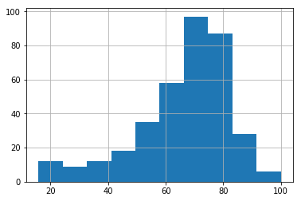

```python
p = combined.frl_percent.hist()
```

```python
combined.frl_percent.value_counts(normalize = True, bins = 6)
```

```
(71.933, 85.967]    0.364641
(57.9, 71.933]      0.331492
(43.867, 57.9]      0.129834
(85.967, 100.0]     0.066298
(29.833, 43.867]    0.058011
(15.715, 29.833]    0.049724
Name: frl_percent, dtype: float64
```

Wow, I didn't realize it was that high. About 43% of schools have at least 72% (round numbers) of their students on free/reduced lunch plans.

#### Some more relationships (Continuing Correlation)

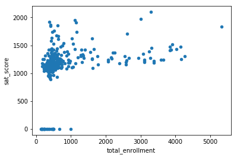

```python
#All the different syntaxes for plotting are starting to annoy me.
p = combined.plot.scatter(x = 'total_enrollment', y = 'sat_score')
```

Looks pretty weak to me. Those 0 SAT scores aren't so believeable. This might be my fault.

```python
combined['sat_score'].min()
```

```
0.0
```

Ah, big miss.

```python
combined[combined['sat_score'] < 100]
```

|  | DBN | SCHOOL NAME | Num of SAT Test Takers | SAT Critical Reading Avg. Score | SAT Math Avg. Score | SAT Writing Avg. Score | sat_score | SchoolName | AP Test Takers | Total Exams Taken | ... | Location 1 | Community Board | Council District | Census Tract | BIN | BBL | NTA | lat | lon | school_dist |
| --- | --- | --- | --- | --- | --- | --- | --- | --- | --- | --- | --- | --- | --- | --- | --- | --- | --- | --- | --- | --- | --- |
| 18 | 02M392 | MANHATTAN BUSINESS ACADEMY | s | 404.035928 | 419.577844 | 399.517964 | 0.0 | 0 | 129.028846 | 197.038462 | ... | 351 West 18 Street\nNew York, NY 10011\n(40.74... | 4.0 | 3.0 | 89.0 | 1013096.0 | 1.007420e+09 | Hudson Yards-Chelsea-Flatiron-Union Square ... | 40.742888 | -74.002127 | 02 |
| 19 | 02M393 | BUSINESS OF SPORTS SCHOOL | s | 404.035928 | 419.577844 | 399.517964 | 0.0 | 0 | 129.028846 | 197.038462 | ... | 439 West 49Th Street\nNew York, NY 10019\n(40.... | 4.0 | 3.0 | 127.0 | 1026646.0 | 1.010590e+09 | Clinton ... | 40.763362 | -73.990509 | 02 |
| 20 | 02M399 | THE HIGH SCHOOL FOR LANGUAGE AND DIPLOMACY | s | 404.035928 | 419.577844 | 399.517964 | 0.0 | 0 | 129.028846 | 197.038462 | ... | 40 Irving Place\nNew York, NY 10003\n(40.73551... | 6.0 | 2.0 | 50.0 | 1017828.0 | 1.008720e+09 | Gramercy ... | 40.735519 | -73.987604 | 02 |
| 31 | 02M427 | MANHATTAN ACADEMY FOR ARTS & LANGUAGE | s | 404.035928 | 419.577844 | 399.517964 | 0.0 | 0 | 129.028846 | 197.038462 | ... | 111 East 33Rd Street\nNew York, NY 10016\n(40.... | 5.0 | 2.0 | 72.0 | 1087537.0 | 1.008898e+09 | Murray Hill-Kips Bay ... | 40.746106 | -73.981010 | 02 |
| 32 | 02M437 | HUDSON HIGH SCHOOL OF LEARNING TECHNOLOGIES | s | 404.035928 | 419.577844 | 399.517964 | 0.0 | 0 | 129.028846 | 197.038462 | ... | 351 West 18 Street\nNew York, NY 10011\n(40.74... | 4.0 | 3.0 | 89.0 | 1013096.0 | 1.007420e+09 | Hudson Yards-Chelsea-Flatiron-Union Square ... | 40.742888 | -74.002127 | 02 |
| 33 | 02M438 | INTERNATIONAL HIGH SCHOOL AT UNION SQUARE | s | 404.035928 | 419.577844 | 399.517964 | 0.0 | 0 | 129.028846 | 197.038462 | ... | 40 Irving Place\nNew York, NY 10003\n(40.73551... | 6.0 | 2.0 | 50.0 | 1017828.0 | 1.008720e+09 | Gramercy ... | 40.735519 | -73.987604 | 02 |
| 56 | 03M402 | THE URBAN ASSEMBLY SCHOOL FOR GREEN CAREERS | s | 404.035928 | 419.577844 | 399.517964 | 0.0 | 0 | 129.028846 | 197.038462 | ... | 145 West 84 Street\nNew York, NY 10024\n(40.78... | 7.0 | 6.0 | 169.0 | 1032128.0 | 1.012150e+09 | Upper West Side ... | 40.785743 | -73.974415 | 03 |
| 57 | 03M403 | THE GLOBAL LEARNING COLLABORATIVE | s | 404.035928 | 419.577844 | 399.517964 | 0.0 | 0 | 129.028846 | 197.038462 | ... | 145 West 84 Street\nNew York, NY 10024\n(40.78... | 7.0 | 6.0 | 169.0 | 1032128.0 | 1.012150e+09 | Upper West Side ... | 40.785743 | -73.974415 | 03 |
| 59 | 03M417 | FRANK MCCOURT HIGH SCHOOL | s | 404.035928 | 419.577844 | 399.517964 | 0.0 | 0 | 129.028846 | 197.038462 | ... | 145 West 84 Street\nNew York, NY 10024\n(40.78... | 7.0 | 6.0 | 169.0 | 1032128.0 | 1.012150e+09 | Upper West Side ... | 40.785743 | -73.974415 | 03 |
| 73 | 05M362 | COLUMBIA SECONDARY SCHOOL FOR MATH, SCIENCE, A... | s | 404.035928 | 419.577844 | 399.517964 | 0.0 | 0 | 129.028846 | 197.038462 | ... | 425 West 123 Street\nNew York, NY 10027\n(40.8... | 9.0 | 7.0 | 20901.0 | 1059526.0 | 1.019640e+09 | Morningside Heights ... | 40.810918 | -73.956927 | 05 |
| 82 | 06M423 | HIGH SCHOOL FOR EXCELLENCE AND INNOVATION | s | 404.035928 | 419.577844 | 399.517964 | 0.0 | 0 | 129.028846 | 197.038462 | ... | 650 Academy Street\nNew York, NY 10034\n(40.86... | 12.0 | 10.0 | 291.0 | 1076776.0 | 1.022330e+09 | Marble Hill-Inwood ... | 40.866046 | -73.924857 | 06 |
| 102 | 08X269 | BRONX STUDIO SCHOOL FOR WRITERS AND ARTISTS | s | 404.035928 | 419.577844 | 399.517964 | 0.0 | 0 | 129.028846 | 197.038462 | ... | 928 Simpson Street\nBronx, NY 10459\n(40.82062... | 2.0 | 17.0 | 89.0 | 2116211.0 | 2.027230e+09 | Hunts Point ... | 40.820624 | -73.893074 | 08 |
| 108 | 08X376 | ANTONIA PANTOJA PREPARATORY ACADEMY, A COLLEGE... | s | 404.035928 | 419.577844 | 399.517964 | 0.0 | 0 | 129.028846 | 197.038462 | ... | 1980 Lafayette Avenue\nBronx, NY 10473\n(40.82... | 9.0 | 18.0 | 16.0 | 2022205.0 | 2.036040e+09 | Soundview-Castle Hill-Clason Point-Harding Par... | 40.822304 | -73.855961 | 08 |
| 110 | 08X432 | BRONX BRIDGES HIGH SCHOOL | s | 404.035928 | 419.577844 | 399.517964 | 0.0 | 0 | 129.028846 | 197.038462 | ... | 1980 Lafayette Avenue\nBronx, NY 10473\n(40.82... | 9.0 | 18.0 | 16.0 | 2022205.0 | 2.036040e+09 | Soundview-Castle Hill-Clason Point-Harding Par... | 40.822304 | -73.855961 | 08 |
| 122 | 09X324 | BRONX EARLY COLLEGE ACADEMY FOR TEACHING & LEA... | s | 404.035928 | 419.577844 | 399.517964 | 0.0 | 0 | 129.028846 | 197.038462 | ... | 250 East 164 Street\nBronx, NY 10456\n(40.8287... | 4.0 | 16.0 | 18302.0 | 2002497.0 | 2.024460e+09 | East Concourse-Concourse Village ... | 40.828714 | -73.917756 | 09 |
| 176 | 12X478 | THE CINEMA SCHOOL | s | 404.035928 | 419.577844 | 399.517964 | 0.0 | 0 | 129.028846 | 197.038462 | ... | 1551 East 172Nd Street\nBronx, NY 10472\n(40.8... | 9.0 | 18.0 | 56.0 | 2117663.0 | 2.038640e+09 | West Farms-Bronx River ... | 40.831365 | -73.878345 | 12 |
| 177 | 12X479 | BRONX CAREER AND COLLEGE PREPARATORY HIGH SCHOOL | s | 404.035928 | 419.577844 | 399.517964 | 0.0 | 0 | 129.028846 | 197.038462 | ... | 800 Home Street\nBronx, NY 10456\n(40.82776397... | 3.0 | 16.0 | 131.0 | 2004868.0 | 2.026710e+09 | Longwood ... | 40.827764 | -73.900387 | 12 |
| 190 | 13K527 | URBAN ASSEMBLY INSTITUTE OF MATH AND SCIENCE F... | s | 404.035928 | 419.577844 | 399.517964 | 0.0 | 0 | 129.028846 | 197.038462 | ... | 283 Adams Street\nBrooklyn, NY 11201\n(40.6946... | 2.0 | 33.0 | 11.0 | 3331741.0 | 3.001400e+09 | DUMBO-Vinegar Hill-Downtown Brooklyn-Boerum Hi... | 40.694620 | -73.988624 | 13 |
| 196 | 14K322 | FOUNDATIONS ACADEMY | s | 404.035928 | 419.577844 | 399.517964 | 0.0 | Foundations Academy | 42.000000 | 53.000000 | ... | 70 Tompkins Avenue\nBrooklyn, NY 11206\n(40.69... | 3.0 | 36.0 | 257.0 | 3048517.0 | 3.017430e+09 | Bedford ... | 40.697061 | -73.946675 | 14 |
| 217 | 15K667 | SUNSET PARK HIGH SCHOOL | s | 404.035928 | 419.577844 | 399.517964 | 0.0 | 0 | 129.028846 | 197.038462 | ... | 153 35Th Street\nBrooklyn, NY 11232\n(40.65595... | 7.0 | 38.0 | 84.0 | 3394175.0 | 3.006880e+09 | Sunset Park West ... | 40.655953 | -74.005497 | 15 |
| 221 | 16K688 | THE BROOKLYN ACADEMY OF GLOBAL FINANCE | s | 404.035928 | 419.577844 | 399.517964 | 0.0 | 0 | 129.028846 | 197.038462 | ... | 125 Stuyvesant Avenue\nBrooklyn, NY 11221\n(40... | 3.0 | 36.0 | 291.0 | 3043822.0 | 3.016160e+09 | Stuyvesant Heights ... | 40.691538 | -73.933726 | 16 |
| 263 | 20K609 | THE URBAN ASSEMBLY SCHOOL FOR CRIMINAL JUSTICE | s | 404.035928 | 419.577844 | 399.517964 | 0.0 | 0 | 129.028846 | 197.038462 | ... | 4200 16 Avenue\nBrooklyn, NY 11204\n(40.634908... | 12.0 | 44.0 | 230.0 | 3125676.0 | 3.053620e+09 | Borough Park ... | 40.634908 | -73.981519 | 20 |
| 268 | 21K468 | KINGSBOROUGH EARLY COLLEGE SCHOOL | s | 404.035928 | 419.577844 | 399.517964 | 0.0 | 0 | 129.028846 | 197.038462 | ... | 2630 Benson Avenue\nBrooklyn, NY 11214\n(40.59... | 13.0 | 47.0 | 306.0 | 3186454.0 | 3.068830e+09 | Gravesend ... | 40.593594 | -73.984729 | 21 |
| 318 | 28Q284 | YORK EARLY COLLEGE ACADEMY | s | 404.035928 | 419.577844 | 399.517964 | 0.0 | 0 | 129.028846 | 197.038462 | ... | 108 35 167 Street\nJamaica, NY 11433\n(40.6969... | 12.0 | 27.0 | 258.0 | 4216655.0 | 4.101780e+09 | South Jamaica ... | 40.696937 | -73.786982 | 28 |
| 320 | 28Q325 | HILLSIDE ARTS & LETTERS ACADEMY | s | 404.035928 | 419.577844 | 399.517964 | 0.0 | 0 | 129.028846 | 197.038462 | ... | 167 01 Gothic Drive\nJamaica, NY 11432\n(40.71... | 8.0 | 24.0 | 452.0 | 4448806.0 | 4.098580e+09 | Briarwood-Jamaica Hills ... | 40.713577 | -73.796518 | 28 |
| 325 | 28Q686 | QUEENS METROPOLITAN HIGH SCHOOL | s | 404.035928 | 419.577844 | 399.517964 | 0.0 | 0 | 129.028846 | 197.038462 | ... | 91 30 Metropolitan Avenue Forest Hills\nNY 113... | 6.0 | 29.0 | 645.0 | 4447233.0 | 4.038861e+09 | Forest Hills ... | 40.710436 | -73.850630 | 28 |
| 334 | 29Q326 | CAMBRIA HEIGHTS ACADEMY | s | 404.035928 | 419.577844 | 399.517964 | 0.0 | 0 | 129.028846 | 197.038462 | ... | 188 04 91St Avenue\nHollis, NY 11423\n(40.7118... | 12.0 | 23.0 | 480.0 | 4222072.0 | 4.104430e+09 | Jamaica ... | 40.711818 | -73.771192 | 29 |
| 337 | 30Q286 | YOUNG WOMEN'S LEADERSHIP SCHOOL, ASTORIA | s | 404.035928 | 419.577844 | 399.517964 | 0.0 | 0 | 129.028846 | 197.038462 | ... | 23 15 Newtown Avenue\nAstoria, NY 11102\n(40.7... | 1.0 | 22.0 | 69.0 | 4440035.0 | 4.005420e+09 | Old Astoria ... | 40.771251 | -73.924602 | 30 |

28 rows × 165 columns

Aha. The component scores are present, but they're all the same. Must have been the mean fill. Didn't recalculate the *sat_score* after. I don't really like the mean fill method. It's nearly 10% of the data. But, it's not *that* much and it's the Dataquest suggestion, so I'll go ahead and keep it.

First, I'll confirm with the original data that the subject scores actually missing and there's not something else going on. Assuming they are, I'll just recalculate *sat_score*

```python
data['sat_results'][data['sat_results']['sat_score'] == 0]
```

|  | DBN | SCHOOL NAME | Num of SAT Test Takers | SAT Critical Reading Avg. Score | SAT Math Avg. Score | SAT Writing Avg. Score | sat_score |
| --- | --- | --- | --- | --- | --- | --- | --- |
| 22 | 02M392 | MANHATTAN BUSINESS ACADEMY | s | NaN | NaN | NaN | 0.0 |
| 23 | 02M393 | BUSINESS OF SPORTS SCHOOL | s | NaN | NaN | NaN | 0.0 |
| 25 | 02M399 | THE HIGH SCHOOL FOR LANGUAGE AND DIPLOMACY | s | NaN | NaN | NaN | 0.0 |
| 38 | 02M427 | MANHATTAN ACADEMY FOR ARTS & LANGUAGE | s | NaN | NaN | NaN | 0.0 |
| 40 | 02M437 | HUDSON HIGH SCHOOL OF LEARNING TECHNOLOGIES | s | NaN | NaN | NaN | 0.0 |
| 41 | 02M438 | INTERNATIONAL HIGH SCHOOL AT UNION SQUARE | s | NaN | NaN | NaN | 0.0 |
| 47 | 02M473 | WASHINGTON IRVING YABC | s | NaN | NaN | NaN | 0.0 |
| 77 | 03M402 | THE URBAN ASSEMBLY SCHOOL FOR GREEN CAREERS | s | NaN | NaN | NaN | 0.0 |
| 78 | 03M403 | THE GLOBAL LEARNING COLLABORATIVE | s | NaN | NaN | NaN | 0.0 |
| 81 | 03M417 | FRANK MCCOURT HIGH SCHOOL | s | NaN | NaN | NaN | 0.0 |
| 89 | 03M577 | YOUNG ADULT BOROUGH CENTER AT LOUIS D. BRANDEI... | s | NaN | NaN | NaN | 0.0 |
| 100 | 05M362 | COLUMBIA SECONDARY SCHOOL FOR MATH, SCIENCE, A... | s | NaN | NaN | NaN | 0.0 |
| 111 | 06M423 | HIGH SCHOOL FOR EXCELLENCE AND INNOVATION | s | NaN | NaN | NaN | 0.0 |
| 122 | 07X379 | JILL CHAIFETZ TRANSFER HIGH SCHOOL | s | NaN | NaN | NaN | 0.0 |
| 123 | 07X381 | BRONX HAVEN HIGH SCHOOL | s | NaN | NaN | NaN | 0.0 |
| 136 | 08X269 | BRONX STUDIO SCHOOL FOR WRITERS AND ARTISTS | s | NaN | NaN | NaN | 0.0 |
| 143 | 08X367 | ARCHIMEDES ACADEMY FOR MATH, SCIENCE AND TECHN... | s | NaN | NaN | NaN | 0.0 |
| 144 | 08X376 | ANTONIA PANTOJA PREPARATORY ACADEMY, A COLLEGE... | s | NaN | NaN | NaN | 0.0 |
| 148 | 08X432 | BRONX BRIDGES HIGH SCHOOL | s | NaN | NaN | NaN | 0.0 |
| 150 | 08X507 | STEVENSON YABC | s | NaN | NaN | NaN | 0.0 |
| 153 | 08X537 | BRONX ARENA HIGH SCHOOL | s | NaN | NaN | NaN | 0.0 |
| 167 | 09X324 | BRONX EARLY COLLEGE ACADEMY FOR TEACHING & LEA... | s | NaN | NaN | NaN | 0.0 |
| 186 | 10X319 | PROVIDING URBAN LEARNERS SUCCESS IN EDUCATION ... | s | NaN | NaN | NaN | 0.0 |
| 201 | 10X478 | LEARNING TO WORK GED AT JOHN F. KENNEDY | s | NaN | NaN | NaN | 0.0 |
| 216 | 11X417 | YOUNG ADULT BOROUGH CNTR CHRISTOPHER COLUMBUS HS | s | NaN | NaN | NaN | 0.0 |
| 219 | 11X456 | LEARNING TO WORK YABC AT TRUMAN HIGH SCHOOL | s | NaN | NaN | NaN | 0.0 |
| 234 | 12X428 | LEARNING TO WORK YABC AT MONROE ACADEMY | s | NaN | NaN | NaN | 0.0 |
| 236 | 12X478 | THE CINEMA SCHOOL | s | NaN | NaN | NaN | 0.0 |
| 237 | 12X479 | BRONX CAREER AND COLLEGE PREPARATORY HIGH SCHOOL | s | NaN | NaN | NaN | 0.0 |
| 254 | 13K527 | URBAN ASSEMBLY INSTITUTE OF MATH AND SCIENCE F... | s | NaN | NaN | NaN | 0.0 |
| 259 | 13K616 | BROOKLYN HIGH SCHOOL FOR LEADERSHIP AND COMMUN... | s | NaN | NaN | NaN | 0.0 |
| 263 | 14K322 | FOUNDATIONS ACADEMY | s | NaN | NaN | NaN | 0.0 |
| 277 | 14K923 | AUTOMOTIVE HIGH SCHOOL YABC | s | NaN | NaN | NaN | 0.0 |
| 286 | 15K529 | WEST BROOKLYN COMMUNITY HIGH SCHOOL | s | NaN | NaN | NaN | 0.0 |
| 289 | 15K667 | SUNSET PARK HIGH SCHOOL | s | NaN | NaN | NaN | 0.0 |
| 295 | 16K688 | THE BROOKLYN ACADEMY OF GLOBAL FINANCE | s | NaN | NaN | NaN | 0.0 |
| 298 | 17K467 | ERASMUS YABC | s | NaN | NaN | NaN | 0.0 |
| 315 | 17K751 | ACADEMY FOR HEALTH CAREERS | s | NaN | NaN | NaN | 0.0 |
| 331 | 19K420 | FRANKLIN K. LANE HIGH SCHOOL | s | NaN | NaN | NaN | 0.0 |
| 332 | 19K431 | THOMAS JEFFERSON YABC | s | NaN | NaN | NaN | 0.0 |
| 348 | 20K609 | THE URBAN ASSEMBLY SCHOOL FOR CRIMINAL JUSTICE | s | NaN | NaN | NaN | 0.0 |
| 354 | 21K412/21K411 | ABRAHAM LINCOLN YABC/LEARNING TO WORK GED AT A... | s | NaN | NaN | NaN | 0.0 |
| 355 | 21K468 | KINGSBOROUGH EARLY COLLEGE SCHOOL | s | NaN | NaN | NaN | 0.0 |
| 380 | 24Q457 | YOUNG ADULT BOROUGH CENTER AT ARTS AND BUSINES... | s | NaN | NaN | NaN | 0.0 |
| 388 | 24Q744 | VOYAGES PREPARATORY | s | NaN | NaN | NaN | 0.0 |
| 416 | 28Q284 | YORK EARLY COLLEGE ACADEMY | s | NaN | NaN | NaN | 0.0 |
| 418 | 28Q325 | HILLSIDE ARTS & LETTERS ACADEMY | s | NaN | NaN | NaN | 0.0 |
| 426 | 28Q686 | QUEENS METROPOLITAN HIGH SCHOOL | s | NaN | NaN | NaN | 0.0 |
| 435 | 29Q326 | CAMBRIA HEIGHTS ACADEMY | s | NaN | NaN | NaN | 0.0 |
| 440 | 30Q286 | YOUNG WOMEN'S LEADERSHIP SCHOOL, ASTORIA | s | NaN | NaN | NaN | 0.0 |
| 468 | 75K371 | P.S. 371 s LILLIAN L. RASHKIS | s | NaN | NaN | NaN | 0.0 |
| 469 | 75M035 | P.S. 035 | s | NaN | NaN | NaN | 0.0 |
| 470 | 75Q256 | P.S. Q256 | s | NaN | NaN | NaN | 0.0 |
| 472 | 75R025 | SOUTH RICHMOND HIGH SCHOOL I.S./P.S. 25 | s | NaN | NaN | NaN | 0.0 |
| 473 | 75X012 | P.S. X012 LEWIS AND CLARK SCHOOL | s | NaN | NaN | NaN | 0.0 |
| 474 | 75X754 | J. M. RAPPORT SCHOOL CAREER DEVELOPMENT | s | NaN | NaN | NaN | 0.0 |
| 475 | 79M645 | SCHOOL FOR COOPERATIVE TECHNICAL EDUCATION | s | NaN | NaN | NaN | 0.0 |

Confirmed.

```python
tonumcols = ['SAT Math Avg. Score','SAT Critical Reading Avg. Score','SAT Writing Avg. Score'] #Just a reminder
combined['sat_score'] = combined[tonumcols].sum(axis = 1)
```

#### If at first you don't succeed, fix your data and redo everything

Well, the correlations and the one plot that didn't look right.

```python
correlations = combined.corr()
correlations = correlations['sat_score']
correlations.sort_values()
```

```
frl_percent                            -0.722714
Local - % of grads                     -0.494469
Still Enrolled - % of cohort           -0.491749
Local - % of cohort                    -0.468445
Dropped Out - % of cohort              -0.458019
Regents w/o Advanced - % of grads      -0.457158
sped_percent                           -0.447413
hispanic_per                           -0.398444
ell_percent                            -0.398248
black_per                              -0.283930
ell_num                                -0.153047
Regents w/o Advanced - % of cohort     -0.141409
lon                                    -0.131803
lat                                    -0.122115
com_p_11                               -0.116765
male_per                               -0.108343
Council District                       -0.074699
Community Board                        -0.062516
postcode                               -0.062054
rr_t                                   -0.024694
grade_span_min                         -0.017890
eng_p_11                                0.019273
hispanic_num                            0.025986
black_num                               0.028702
aca_p_11                                0.033644
eng_t_11                                0.034650
sped_num                                0.036052
CSD                                     0.044799
BBL                                     0.046673
rr_p                                    0.046779
Census Tract                            0.049165
BIN                                     0.054450
com_tot_11                              0.074869
com_t_11                                0.080251
eng_tot_11                              0.098118
female_per                              0.108389
number_programs                         0.117964
saf_p_11                                0.121469
aca_t_11                                0.130313
com_s_11                                0.186068
```

[output cut: 31 more lines]

```
Advanced Regents - % of cohort          0.771787
SAT Math Avg. Score                     0.972664
SAT Critical Reading Avg. Score         0.986821
SAT Writing Avg. Score                  0.987835
sat_score                               1.000000
SCHOOLWIDE PUPIL-TEACHER RATIO               NaN
schoolyear                                   NaN
fl_percent                                   NaN
grade_span_max                               NaN
expgrade_span_min                            NaN
expgrade_span_max                            NaN
priority08                                   NaN
priority09                                   NaN
priority10                                   NaN
Name: sat_score, dtype: float64
```

Well, this is substantially different (more the strength than the direction/order). This explains why the component score correlations with *sat_score* were so weak before. The race-based differences got enough stronger. *male_per* and *female_per* are now more different from one another, though neither correlations are particularly strong.

Let's look at the total_enrollment plot again and see if grahpically we now see a stronger correlation.

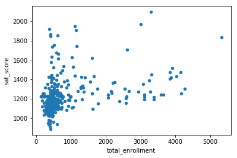

```python
p = combined.plot.scatter(x = 'total_enrollment', y = 'sat_score')
```

```python
np.mean(combined['sat_score'])
```

```
1223.131736526946
```

Well, a little something. It's really variable for the schools with total enrollment under about 1000. From enrollment of 1,000 to about 4,000, SAT scores are at or a bit above the overall average, with a few standouts.

Let's look at the little batch of schools with really low SAT scores (and low enrollment)

```python
low_enrollment = combined[(combined['total_enrollment'] < 1000) & (combined['sat_score'] < 1000)]

low_enrollment['School Name']
```

```
90       INTERNATIONAL COMMUNITY HIGH SCHOOL
124                                        0
125          BRONX INTERNATIONAL HIGH SCHOOL
138    KINGSBRIDGE INTERNATIONAL HIGH SCHOOL
140    INTERNATIONAL SCHOOL FOR LIBERAL ARTS
175                                        0
178            HIGH SCHOOL OF WORLD CULTURES
187       BROOKLYN INTERNATIONAL HIGH SCHOOL
224    INTERNATIONAL HIGH SCHOOL AT PROSPECT
236               IT TAKES A VILLAGE ACADEMY
252                MULTICULTURAL HIGH SCHOOL
285    PAN AMERICAN INTERNATIONAL HIGH SCHOO
Name: School Name, dtype: object
```

Ah... I see the word **International** a lot. Which may mean a lot of English as a second language learners. Let's see how the *ell_percent* (Percentage of english language learner's students per school) variable correlates with SAT scores.

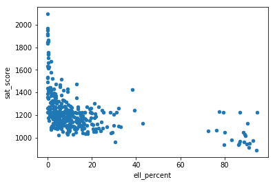

```python
p = combined.plot.scatter(x = 'ell_percent', y = 'sat_score')
```

```python
longitudes = combined['lon'].tolist()
latitudes  = combined['lat'].tolist()
```

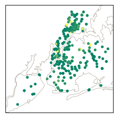

```python
m = Basemap(
    projection='merc',
    llcrnrlat=40.496044,
    urcrnrlat=40.915256,
    llcrnrlon=-74.255735,
    urcrnrlon=-73.700272,
    resolution='h'
)

m.drawmapboundary(fill_color='#FFFFFF')
m.drawcoastlines(color='#6D5F47', linewidth=.4)
m.drawrivers(color='#6D5F47', linewidth=.4)

p = m.scatter(longitudes, latitudes, s = 20, zorder = 2, latlon = True, c = combined['ell_percent'], cmap = 'summer')
```

```python
districts = combined.groupby('school_dist').agg(np.mean)
districts.reset_index(inplace = True)
districts.head()
```

|  | school_dist | SAT Critical Reading Avg. Score | SAT Math Avg. Score | SAT Writing Avg. Score | sat_score | AP Test Takers | Total Exams Taken | Number of Exams with scores 3 4 or 5 | Total Cohort | Total Grads - % of cohort | ... | priority08 | priority09 | priority10 | Community Board | Council District | Census Tract | BIN | BBL | lat | lon |
| --- | --- | --- | --- | --- | --- | --- | --- | --- | --- | --- | --- | --- | --- | --- | --- | --- | --- | --- | --- | --- | --- |
| 0 | 01 | 441.833333 | 473.333333 | 439.333333 | 1354.500000 | 116.681090 | 173.019231 | 135.800000 | 93.500000 | 71.333333 | ... | 0.0 | 0.0 | 0.0 | 3.000000 | 1.500000 | 1106.833333 | 1.004144e+06 | 1.003302e+09 | 40.719022 | -73.982377 |
| 1 | 02 | 426.608658 | 444.176397 | 424.814746 | 1295.599800 | 128.908454 | 201.516827 | 157.495833 | 158.713390 | 75.438767 | ... | 0.0 | 0.0 | 0.0 | 4.203762 | 2.964120 | 1132.687384 | 1.104040e+06 | 1.070612e+09 | 40.739699 | -73.991386 |
| 2 | 03 | 428.508982 | 437.977794 | 426.879491 | 1293.366267 | 156.183494 | 244.522436 | 193.087500 | 183.496764 | 74.004553 | ... | 0.0 | 0.0 | 0.0 | 7.500000 | 6.500000 | 166.666667 | 1.034931e+06 | 1.012833e+09 | 40.781574 | -73.977370 |
| 3 | 04 | 397.166667 | 411.333333 | 398.666667 | 1207.166667 | 129.014423 | 181.685897 | 150.633333 | 123.666667 | 72.300000 | ... | 0.0 | 0.0 | 0.0 | 11.000000 | 8.000000 | 3047.833333 | 1.056517e+06 | 1.016738e+09 | 40.793572 | -73.942534 |
| 4 | 05 | 427.147990 | 438.225406 | 419.645423 | 1285.018820 | 85.722527 | 115.725275 | 142.464286 | 143.805825 | 75.171870 | ... | 0.0 | 0.0 | 0.0 | 9.428571 | 8.142857 | 9372.571429 | 1.063080e+06 | 1.019721e+09 | 40.817077 | -73.949251 |

5 rows × 86 columns

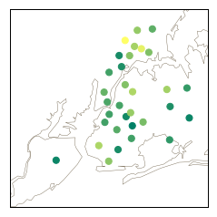

```python
m = Basemap(
    projection='merc',
    llcrnrlat=40.496044,
    urcrnrlat=40.915256,
    llcrnrlon=-74.255735,
    urcrnrlon=-73.700272,
    resolution='h'
)

m.drawmapboundary(fill_color='#FFFFFF')
m.drawcoastlines(color='#6D5F47', linewidth=.4)
m.drawrivers(color='#6D5F47', linewidth=.4)

longitudes = districts['lon'].tolist()
latitudes  = districts['lat'].tolist()

p = m.scatter(longitudes, latitudes, s = 50, zorder = 2, latlon = True, c = districts['ell_percent'], cmap = 'summer')
```

## Exploratory Analysis

#### Relationship between SAT scores and perceived safety

First, we'll look at correlations between *sat_score* and answers to survey responses.

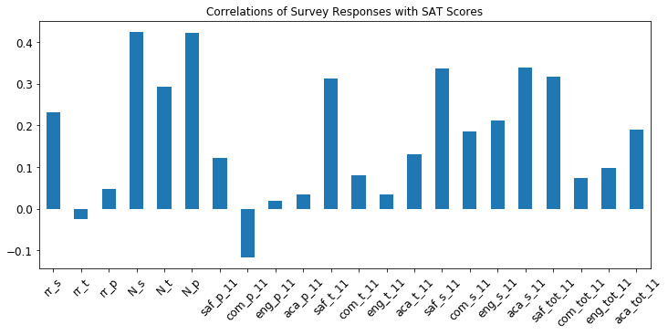

```python
surveynames = data['survey'].columns.tolist()
surveynames.insert(1,'sat_score')
p = pd.DataFrame(combined.loc[:,surveynames].corr()['sat_score']) \
    .iloc[1:,:] \
    .plot(kind = 'bar', legend = False, \
          title = 'Correlations of Survey Responses with SAT Scores', rot = 45, figsize = (12,5), fontsize = 12)
```

Some of the higher correlations are:

**N_s**  
Number of Student Respondents. Ah. We did some some evidence that larger schools had higher SAT scores, so this is really just a function of that (we might find otherwise if it happens that these schools have higher survey responses, and we could take it as some other sign of engagement, but chances are it's just school size).

**N_p**  
Number of Parent Respondents. Same as *N_s*

**aca_s_11**  
Academic expectations score based on student responses. In other words, how did students feel about what they were expected to achieve. So, there is a positive relationship between high expectations and higher SAT scores. I can buy that.

**saf_s_11 / saf_t_11 / saf_tot_11**  
Safety and respect based on student/teacher/total responses. In a way, it's nice to see these on the list. It's intuitive that students who feel more safe will be able to concentrate more on academics. The flip side is that students who don't feel safe don't do as well, and we have students who don't feel safe. But, we have the opportunity to identify that using this data, which is part of the benefit.

These are all positive. There are only a couple of negative correlations, and the strongest is only about -0.1, but since it's the only one in that direction let's talk about it:

**com_p_11** Communicaton score based on parent responses. It's a weak relationship, but still funny to see this here. A negative relationship between how parents feel the school is communicating and SAT scores.

#### Dig deeper into safety scores

These show up quite a bit. Let's visualize the relationship beyond just a single figure correlation.

Investigate safety scores. Compute the average safety score for each district. Make a map that shows safety scores by district. Write up your conclusions about safety by geographic area in a Markdown cell. You may want to read up on the boroughs of New York City.

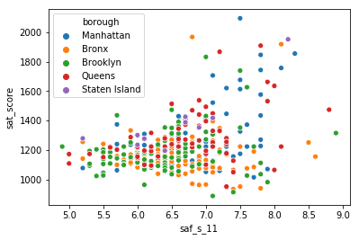

```python
s = sns.scatterplot(x = combined['saf_s_11'], y = combined['sat_score'], hue = combined['borough'])
```

Well, It's not clear that the safety to sat_score relationship holds up all that well. After safety reaches 7, there is a lot of variation in *sat_scores*. Maybe safety is something that only matters when it doesn't exist. When the score gets past 7, safety becomes less important. There isn't much relationship at all between the 2 variables from 5-7 or from 7-9... some, but not much. It only starts to look stronger as a whole.

And, it's hard to tell with the colors, but it's not immediately clear that schools from any of the five boroughs are more or less safe on average than others. A map may help with that.

```python
safetybydistrict = combined.loc[:, ['school_dist','lat','lon','saf_s_11']]
safetybydistrict = safetybydistrict.groupby('school_dist').agg(np.mean)
```

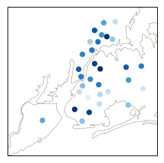

```python
m = Basemap(
    projection='merc',
    llcrnrlat=40.496044,
    urcrnrlat=40.915256,
    llcrnrlon=-74.255735,
    urcrnrlon=-73.700272,
    resolution='h'
)

m.drawmapboundary(fill_color='#FFFFFF')
m.drawcoastlines(color='#6D5F47', linewidth=.4)
m.drawrivers(color='#6D5F47', linewidth=.4)

longitudes = safetybydistrict['lon'].tolist()
latitudes  = safetybydistrict['lat'].tolist()

#combined['district_num'] = combined['school_dist'].astype('category').cat.codes
m = m.scatter(longitudes, latitudes, s = 50, zorder = 2, latlon = True, c = safetybydistrict['saf_s_11'], cmap = 'Blues')
```

Where darker is more safe, it doesn't look like there's any completely obvious split between boroughs. Brooklyn/Queens to the bottom right of the map do have a few of the less-safe school districts.

This is partly a result of the "mean by school district" look. Below, I show what happens... there's not a lot of variation from one school district to another. The range of the means is only about 1.25 points (on the 10 point survey scale).

```python
safetybydistrict.saf_s_11.describe()
```

```
count    32.000000
mean      6.581535
std       0.355723
min       5.875000
25%       6.294048
50%       6.641136
75%       6.827652
max       7.120000
Name: saf_s_11, dtype: float64
```

#### Relationship between SAT scores and race

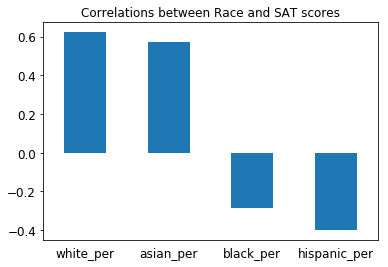

```python
pd.DataFrame(combined[['sat_score','white_per','asian_per','black_per','hispanic_per']].corr()['sat_score']) \
    .iloc[1:,:] \
    .plot(kind = 'bar', legend = False, title = 'Correlations between Race and SAT scores', rot = 0, fontsize = 12) \
    .tick_params(bottom = False)
```

We'd done some passive review of these earlier. There is a somewhat strong positive correlation with SAT scores and a school's proportion of white/asian students, and a negative correlation between SAT scores and proportion of black/hispanic students.

We'll explore *hispanic_per* below.

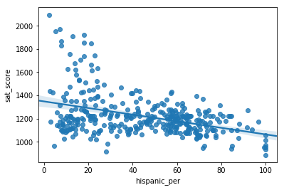

```python
s = sns.regplot(x = combined['hispanic_per'], y = combined['sat_score'])
```

Here I've added a regression line. As we'd expect given the correlation we saw, the line has a negative slope. There are some schools below about 25% hispanic students with high SAT scores. After 25% things steady off, with what looks like a less steep decrease (just looking at the points - ignoring the line here) up to just short of 100%. The schools at 100% have uniformly low SAT scores. Let's find out more about those schools.

```python
combined.loc[combined['hispanic_per'] > 95, ['school_name','sat_score', 'hispanic_per']]
```

|  | school_name | sat_score | hispanic_per |
| --- | --- | --- | --- |
| 44 | Manhattan Bridges High School | 1058.0 | 99.8 |
| 81 | Washington Heights Expeditionary Learning School | 1174.0 | 96.7 |
| 88 | Gregorio Luperon High School for Science and M... | 1014.0 | 99.8 |
| 124 | Academy for Language and Technology | 951.0 | 99.4 |
| 140 | International School for Liberal Arts | 934.0 | 99.8 |
| 175 | Pan American International High School at Monroe | 970.0 | 99.8 |
| 252 | Multicultural High School | 887.0 | 99.8 |
| 285 | Pan American International High School | 951.0 | 100.0 |

I looked for more information about a couple of these schools.

**Multicultural High School**

The name is something of a misnomer, as virtually every student at the school is Hispanic. Many of the students at the school are foreign-born and English is not their first language.

**International School for Liberal Arts**

Despite low test scores and many International students, I found two bits of information I think were interesting, if not informative.

1 - Despite test scores being low across subjects (and outside of just the SATs), only 14% of the students are actually taking SATs. I've explored data in the past where schools with low SAT participation tended to have higher average SAT scores, because students who would do well were encouraged to take it and other students were discouraged. This is why state level results must be taken with a grain of salt - some states require that all students take the SATs. Those states tend to have lower average SAT scores. So, it was surprising to me that the scores were low with this level of participation, but of course the international/language factor is a likely influence.

2 - This doesn't help with the data analysis much, but despite scoring low in academics, this school scores highly (on greatschools, anyway) for Academic Progress. So those low academic scores are for students that were not doing as well the year prior.

Now I'll do the same thing for schools with high SAT scores and a low proportion of hispanic students. How do these schools differ?

```python
combined.loc[(combined['hispanic_per'] < 10) & (combined['sat_score'] > 1800), ['school_name','sat_score','hispanic_per']]
```

|  | school_name | sat_score | hispanic_per |
| --- | --- | --- | --- |
| 37 | Stuyvesant High School | 2096.0 | 2.4 |
| 150 | Bronx High School of Science | 1969.0 | 7.2 |
| 186 | Brooklyn Technical High School | 1833.0 | 7.9 |
| 326 | Queens High School for the Sciences at York Co... | 1868.0 | 7.9 |
| 355 | Staten Island Technical High School | 1953.0 | 5.3 |

These are specialized high schools in New York. Every single one is selective, requiring students to score highly on an admissions test. A couple of them even have *Reputation* sections on Wikipedia.

#### Relationship between SAT scores and gender

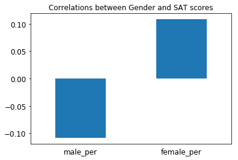

```python
pd.DataFrame(combined[['sat_score','male_per','female_per']].corr()['sat_score']).iloc[1:,:] \
    .plot(kind = 'bar', legend = False, title = 'Correlations between Gender and SAT scores', rot = 0, fontsize = 12) \
    .tick_params(bottom = False)
```

Though these relationships are fairly week, we see a positive relationship between a school having a higher proportion of female students and SAT scores.

Plotting both of these works for a visual, but each of male_per and female_per is 1 minus the other, so the relationship has equal strength in either direction.

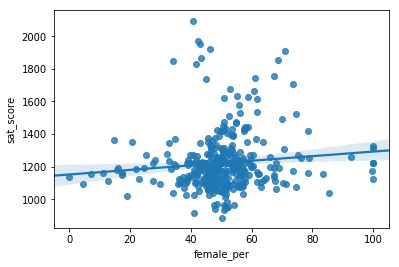

```python
s = sns.regplot(x = combined['female_per'], y = combined['sat_score'])
```

Not the most compelling evidence. Most schools fall in the 40-60 pct gender proportion range. There are clusters of schools with high SAT scores that have majority male or female students. The all-female schools do look slightly above average as a group, but only slightly.

```python
combined.loc[(combined['female_per'] > 60) & (combined['sat_score'] > 1700), ['school_name','sat_score','female_per']]
```

|  | school_name | sat_score | female_per |
| --- | --- | --- | --- |
| 5 | Bard High School Early College | 1856.0 | 68.7 |
| 26 | Eleanor Roosevelt High School | 1758.0 | 67.5 |
| 60 | Beacon High School | 1744.0 | 61.0 |
| 61 | Fiorello H. LaGuardia High School of Music & A... | 1707.0 | 73.6 |
| 301 | Townsend Harris High School | 1910.0 | 71.1 |

Again, the high performing schools are the selective schools. Townsend Harris High School is ranked (if you like the US News & World Report) as the top school in the state, and its admission rate is about half that of Harvard's.

#### Relationship between SAT scores and Advanced Placement

Calculate the percentage of students in each school that took an AP exam. Divide the AP Test Takers column by the total_enrollment column. The column name AP Test Takers has a space at the end -- don't forget to add it! Assign the result to the ap_per column. Investigate the relationship between AP scores and SAT scores. Make a scatter plot of ap_per vs. sat_score. What does the scatter plot show? Record any interesting observations in a Markdown cell.

```python
combined['ap_per'] = combined['AP Test Takers '] / combined['total_enrollment']
```

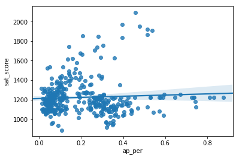

```python
s = sns.regplot(x = combined['ap_per'], y = combined['sat_score'])
```

Not much of a *linear* relationship. Well, not much of a recognizable relationship of any kind. When over 50% or so of students take AP exams, the schools seem to score about 1200 on the SATs. Seems like some schools might be a bit more focused on having students take AP exams.

I am curious about the cluster with great than 40% of students taking AP exams and getting high SAT scores. Almost certainly the competitive specialized schools again. I'll check this first because I expect the result will be familiar.

```python
combined.loc[(combined['sat_score'] > 1800) & (combined['ap_per'] > 0.4), ['school_name','sat_score','ap_per']]
```

|  | school_name | sat_score | ap_per |
| --- | --- | --- | --- |
| 37 | Stuyvesant High School | 2096.0 | 0.457992 |
| 154 | High School of American Studies at Lehman College | 1920.0 | 0.514589 |
| 301 | Townsend Harris High School | 1910.0 | 0.537719 |
| 326 | Queens High School for the Sciences at York Co... | 1868.0 | 0.514354 |
| 355 | Staten Island Technical High School | 1953.0 | 0.478261 |

Next, looking at schools with high *ap_per*

```python
combined.loc[combined['ap_per'] > 0.70, ['school_name','sat_score','ap_per']]
```

|  | school_name | sat_score | ap_per |
| --- | --- | --- | --- |
| 6 | 47 The American Sign Language and English Seco... | 1182.000000 | 0.741545 |
| 31 | MANHATTAN ACADEMY FOR ARTS & LANGUAGE | 1223.131737 | 0.737308 |
| 33 | International High School at Union Square | 1223.131737 | 0.733118 |
| 82 | High School for Excellence and Innovation | 1223.131737 | 0.724881 |
| 110 | BRONX BRIDGES HIGH SCHOOL | 1223.131737 | 0.832444 |
| 207 | Frances Perkins Academy | 1122.000000 | 0.745831 |
| 221 | The Brooklyn Academy of Global Finance | 1223.131737 | 0.811502 |
| 334 | Cambria Heights Academy | 1223.131737 | 0.877747 |

Interesting. Some of these are selective, but not in the way we've seen. The Frances Perkins Academy is mostly "economically disadvantaged" students (wording from US News). The Brooklyn Academy of Global Finance does have an application process, but it's not on the same level as the schools producing much higher SAT scores.